# Evaluation Deliverable template

## I. Impact, applicability and creativity

### 1. Challenge solved

The main challenge we hope to solve is incrasing the adhesion of the Matosinhos' population to micromobility types of transport, such as public bycicles and scooters. We think that this adhesion could be promoted with specific targeting, with an otimization in the choice of pickup areas and publicity more focused on the people of interest.

### 2. Proposed solution

We propose the use of multiple variables, namely demographic data, average flow and average distance traveled and the geographic relief of each of Matosinho's localities in order to distinguish areas with a higher probability of adopting scooters or bike for their mobility, allowing not only a better selection of pick up points and number of resources available, but also a way to target communication towards those with higher probability of using a bike or scooter on their commutes (raising efficient awareness). After establishing these parameters, we can predict the number of trips that could be completed with micromobility and predict the CO2 impact of this change. Moreover, we could boost even more the use of micromobility, by applying some marketing strategies such as a close relationship between this otimzation method and the app AYR, which allows the implementation of a cashback/ voucher strategy for future trips or other services, based on the CO2 emissions avoided with that trip, the integration of micromobility transports in the regional public transportation network (Andante), which promotes integration of micromobility on the large scale of mobility and allows a better communication between different transportation methods and, finally, improving user experience by suggesting the ideal microbility transportation method (bike or scooter) for the specified route.

### 3. How to apply your solution in practice

In practice, this solution could be applied easily and in a similar way we developed this first draft of their project. The project could be improved with more localities characteristics, such as the number and frequency of buses, as well as data from the typicl user of these type of transportation. The solution would be used to find the optimal distribution of scooters and bikes throught Matosinhos' localities based on demographic and geological and mobility factors we believe will promote the use of this kind of transportation and grounded on the necessity of mobility, which can be assessed with the daily flow out of that locality. The functionality of helping the user choose between the bike and the scooter can be integrated in the micromobility app, and decides on the best option based on the time of the year, geographic relief and distance.

With Ceiia and the Matosinhos Municipality as partners, it would be easy to implement our other two ideas, since the methods for the calculus of the cashback based on saved CO2 emissions were already developed by Ceiia and the Municipality, possibly in a partnership with Ceiia, could push towards the integration of micromobility resources in the network of public transportation.

### 4. Estimated impact of the solution (Quantitative and qualitative results)

With our models, we estimated that, if we keep the penetration rate equal to the maximum from the pilot, Matosinhos could have an emission reduction impact 3.5x bigger than the impact generated in the pilot. However, this could only happen if all flows with high probability of transitioning to micromobility did, in fact, transition and if there could be provided 660 bike rides and 660 scooter rides per day in total in the city. Nevertheless, even if we only use the city's current resources (27 bikes, 1475 scooters), we can expect an overall CO2 reduction of 145kg/day (2.3x the pilot impact) during summer time, simply by optimizing the fleet (positioning of scooters and bike distribution centers) and by targeting communication.

## II. Analytical component

Import Libraries

```python
from google.cloud import bigquery
import numpy as np
import pandas as pd
import seaborn as sns
from statsmodels.stats import weightstats as stests
from mlxtend.evaluate import bias_variance_decomp
import datetime
import matplotlib.pyplot as plt
from tqdm.notebook import tqdm_notebook
import pandas as pd
import pickle
from io import StringIO
from sklearn.model_selection import train_test_split
from sklearn.preprocessing import StandardScaler
from collections import Counter
import pandas as pd
import numpy as np
import sklearn
from sklearn.decomposition import PCA
from sklearn import svm
from sklearn.decomposition import KernelPCA
from sklearn.linear_model import LogisticRegression
from sklearn.ensemble import RandomForestClassifier
from sklearn.metrics import accuracy_score, roc_auc_score, balanced_accuracy_score, precision_score, recall_score, f1_score, plot_confusion_matrix, plot_roc_curve, accuracy_score
import matplotlib.pyplot as plt
import sklearn
from sklearn.utils import resample
from sklearn.tree import DecisionTreeClassifier
from sklearn.metrics import accuracy_score, multilabel_confusion_matrix, auc, roc_auc_score, roc_curve, confusion_matrix, precision_score, recall_score, f1_score, plot_confusion_matrix, plot_roc_curve, classification_report
from statistics import mean
from sklearn.preprocessing import MinMaxScaler
from sklearn.linear_model import LinearRegression
from sklearn.svm import SVR
from sklearn.preprocessing import StandardScaler
from sklearn.model_selection import train_test_split, GridSearchCV
import numpy as np
import pandas as pd
from sklearn.metrics import mean_absolute_error, r2_score, mean_squared_error, mean_absolute_percentage_error
import matplotlib.pyplot as plt
import geopandas as gpd
import pandas as pd
import os
from pyproj import Proj, transform
from google.cloud import bigquery
import numpy as np
import seaborn as sns
from statsmodels.stats import weightstats as stests
import datetime
from pulp import LpMaximize, LpProblem, LpStatus, lpSum, LpVariable
import random
import pandas as pd
import matplotlib.pyplot as plt
import geopandas
from shapely import wkb
from shapely import geometry
from tqdm.notebook import tqdm
%load_ext google.cloud.bigquery
pd.set_option('display.max_rows', 1000)
pd.set_option('display.max_columns', 500)

bqclient = bigquery.Client()
```

```
The google.cloud.bigquery extension is already loaded. To reload it, use:
  %reload_ext google.cloud.bigquery
```

### I. Predictive component

```python
query= """
SELECT * FROM eurekathon-hub.CEIIA.shared_micromobility
"""

all_data = (
    bqclient.query(query)
    .result()
    .to_dataframe()
)

all_data.head(5)
```

|  | vehicle_id | session_id | type | start_time | end_time | distance | saved_emissions | route |
| --- | --- | --- | --- | --- | --- | --- | --- | --- |
| 0 | 256 | 70c1da29-f770-48e7-bb2e-e730530df253 | E-SCOOTER | 1559416935000 | 1559417360000 | 1184.000000000 | 108.620160000 | 0104000000230000000101000000000000C0FC6021C000... |
| 1 | 256 | 50c8da23-1aa9-4709-b00a-7f92edb582af | E-SCOOTER | 1559234619000 | 1559236460000 | 1064.000000000 | 97.611360000 | 010400000022000000010100000000000080E95D21C000... |
| 2 | 256 | d431ff2a-5b10-4e5f-830a-897f6d7c092c | E-SCOOTER | 1559263312000 | 1559265548000 | 4120.000000000 | 377.968800000 | 01040000007D000000010100000000000060EB5B21C000... |
| 3 | 256 | b8d9eb23-b839-4345-a095-80bbc8348a87 | E-SCOOTER | 1563065085000 | 1563065221000 | 368.000000000 | 33.760320000 | 010400000035000000010100000000000040CE4F21C000... |
| 4 | 256 | 14eeda55-c31a-4f33-83a6-0de7f045e9ee | E-SCOOTER | 1562771829000 | 1562772707000 | 3152.000000000 | 289.164480000 | 010400000069000000010100000000000080335021C000... |

```python
df = all_data.copy()
```

#### 1. Exploratory Data Analysis

##### Duplicates

```python
#Check number of occurrences for each session_id
df.groupby(by='session_id')['type'].count()
```

```
session_id
000205b3-6b38-4885-b432-58e6bb815ac2    2
00020e91-c63a-479a-9e0f-818d305a78ef    1
00026b0a-ae11-41da-895c-46f7ca755f52    1
00026f8a-b3d2-4c71-8606-c7a1236474bd    1
0002f64a-be86-49dd-9914-d4b8dc0b32fa    2
                                       ..
fffa6c87-4031-4551-9f35-681c655a4cc9    2
fffd00ef-3e18-437f-a6c2-4f1801a1bf89    2
fffd5cc4-d04c-4002-90c4-b4abc849b169    1
ffff53c4-cf0c-4efd-b818-342ceec7abcd    1
ffff7bce-e563-4c57-a175-0646c892c029    1
Name: type, Length: 108481, dtype: int64
```

```python
# Check one session_id that has more than one occurrence
df.loc[df['session_id']=='000205b3-6b38-4885-b432-58e6bb815ac2']
```

|  | vehicle_id | session_id | type | start_time | end_time | distance | saved_emissions | route |
| --- | --- | --- | --- | --- | --- | --- | --- | --- |
| 44441 | 2107 | 000205b3-6b38-4885-b432-58e6bb815ac2 | E-SCOOTER | 1574085964000 | 1574087825000 | 824.000000000 | 75.651440000 | 0104000000C6020000010100000000000060FD5F21C000... |
| 52744 | 2107 | 000205b3-6b38-4885-b432-58e6bb815ac2 | E-SCOOTER | 1574085964000 | 1574087825000 | 824.000000000 | 75.651440000 | 0104000000C6020000010100000000000060FD5F21C000... |

##### Data Cleaning

```python
#Remove Duplicates
df = df.drop_duplicates(subset=['session_id'])

#Eliminate null values
df = df.replace('NULL', None)
df = df.dropna()

#Convert timestamp to datetime
df['start_time'] = df['start_time'].apply(lambda x: x[:10])
df['start_time'] = df['start_time'].values.astype(dtype='int')
df['start_time'] = df['start_time'].apply(lambda x: datetime.datetime.fromtimestamp(x))

df['end_time'] = df['end_time'].apply(lambda x: x[:10])
df['end_time'] = df['end_time'].values.astype(dtype='int')
df['end_time'] = df['end_time'].apply(lambda x: datetime.datetime.fromtimestamp(x))

#Clean wrong times (end time should be after start time, but there are several cases where this does not verify)
df = df.loc[df['end_time'] > df['start_time']]

#Class encoding:
 # 0 - escooter
 # 1 - scooter
 # 2 - bike
df['Label'] = df['type'].apply(lambda label: 2 if label == 'BIKE' else (1 if label=='SCOOTER' else 0))

#Converting string to int
df['saved_emissions']=df['saved_emissions'].values.astype(dtype='int')

#Eliminate null values
df = df.replace('NULL', None)
df = df.dropna()

# We assumed that distances smaller than 25 meters and bigger than 10Km should not be considered in our analysis.
df['distance'] = df['distance'].values.astype(dtype='int')
df = df.loc[(df['distance'] > 25) & (df['distance'] < 10000)]
```

##### Seasons of the Year

```python
def get_season(date, return_name=False):

    #Encode a datatime object into season of the year (0 - spring, 1 - summer, 2 - autumn, 3 - winter)

    if date.month < 3:
        year = int(date.year -1)
    else:
        year = int(date.year)

    spring = {'season': 'spring', 'id': 0, 'start': datetime.datetime(year, 3, 20), 'end': datetime.datetime(year, 6, 20)}
    summer = {'season': 'summer', 'id': 1, 'start': datetime.datetime(year, 6, 21), 'end': datetime.datetime(year, 9, 22)}
    autumn = {'season': 'autumn', 'id': 2, 'start': datetime.datetime(year, 9, 23), 'end': datetime.datetime(year, 12, 20)}
    winter = {'season': 'winter', 'id': 3, 'start': datetime.datetime(year, 12, 21), 'end': datetime.datetime(year+1, 3, 18)}

    if date >= spring['start'] and date <= spring['end']:
        season_name = 'Spring'
        season_code = spring['id']
    elif date >= summer['start'] and date <= summer['end']:
        season_name = 'Summer'
        season_code = summer['id']
    elif date >= autumn['start'] and date <= autumn['end']:
        season_name = 'Autumn'
        season_code = autumn['id']
    else:
        season_name = 'Winter'
        season_code = winter['id']

    if return_name:
        return season_name
    else:
        return season_code
```

##### Adherence to Micromobility over time

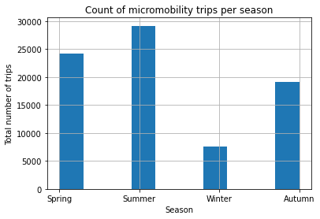

```python
fig, ax = plt.subplots()
df['start_time'].apply(lambda x: get_season(x, return_name=True)).hist(ax=ax)
ax.set_title("Count of micromobility trips per season")
ax.set_xlabel('Season')
ax.set_ylabel('Total number of trips')
```

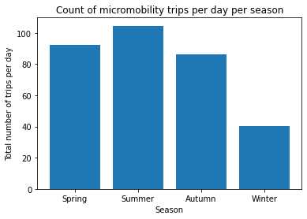

```python
counts_per_season = dict(Counter(df['season']))
counts_per_season = [counts_per_season[key] for key in sorted(counts_per_season.keys())]

date = df['start_time'].min()
days_s = []
while date <= df['start_time'].max():
    days_s.append(get_season(date))
    date += datetime.timedelta(days=1)

# total days in the time frame we have for each season
days_per_season = dict(Counter(days_s))
days_per_season = [days_per_season[key] for key in sorted(days_per_season.keys())]

counts_per_day = [trips / days for trips, days in zip(counts_per_season, days_per_season)]
counts_per_day

seasons = ['Spring', 'Summer', 'Autumn', 'Winter']
fig, ax = plt.subplots()
plt.bar(seasons, counts_per_day)
ax.set_title("Count of micromobility trips per day per season")
ax.set_xlabel('Season')
ax.set_ylabel('Total number of trips per day')
```

##### Routes

Another variable also considered in the problem was the root of each micromobility movement:

1. It enabled us to filter the location of each movement to the ones that included Matosinhos (a total of 29.597 movements were from Lisbon),
2. It made possible the calculation of the Cota's of the start and end point of each route. With this, the difference of those was calculated and another relevant feature was created: delta Z.

(More details above)

```python
df = pd.read_pickle('df_delta_z_final.pkl')
#Encode seasons of the year
df['season'] = df['start_time'].apply(lambda x: get_season(x))
df.head(5)
```

|  | type | distance | start_time | saved_emissions | Label | delta_z | session_id | season |
| --- | --- | --- | --- | --- | --- | --- | --- | --- |
| 1 | E-SCOOTER | 1064 | 2019-05-30 16:43:39 | 97 | 0 | -21.71 | 50c8da23-1aa9-4709-b00a-7f92edb582af | 0 |
| 7 | E-SCOOTER | 3931 | 2019-06-02 20:21:16 | 360 | 0 | 0.00 | c35b3152-b72b-4aa9-ba86-546ed2ae9d36 | 0 |
| 9 | E-SCOOTER | 450 | 2019-06-09 17:55:06 | 41 | 0 | 0.00 | df1186f5-9a6b-469e-a83e-d0c6deacb156 | 0 |
| 10 | E-SCOOTER | 132 | 2019-06-05 09:46:18 | 12 | 0 | 0.00 | 5a1584ba-2ef6-430d-a8fc-0ac6f4e49bcc | 0 |
| 11 | E-SCOOTER | 4126 | 2019-05-28 15:01:07 | 378 | 0 | 0.00 | b313e6ba-d69a-4953-a170-814bcb99b219 | 0 |

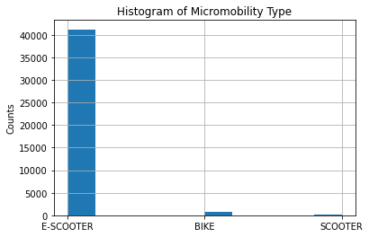

```python
fig, ax = plt.subplots()
df['type'].hist(ax=ax)
ax.set_title('Histogram of Micromobility Type')
ax.set_ylabel('Counts')
```

##### Emission Model Feature Analysis

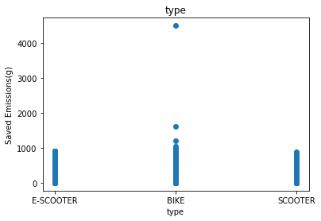

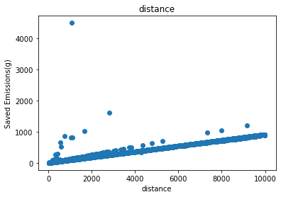

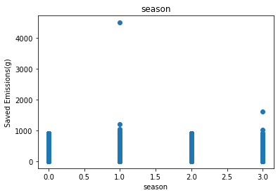

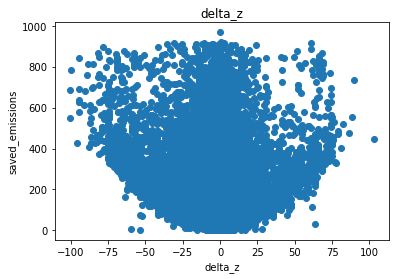

```python
for feat in ['type', 'distance', 'season', 'delta_z']:

    if feat!='delta_z':
        plt.figure()
        plt.scatter(df[feat], df['saved_emissions'])
        plt.title(feat)
        plt.xlabel(feat)
        plt.ylabel('Saved Emissions(g)')
    else:
        plt.figure()
        plt.scatter(df.loc[df['saved_emissions']<1000]['delta_z'], df.loc[df['saved_emissions']<1000]['saved_emissions'])
        plt.title('delta_z')
        plt.xlabel('delta_z')
        plt.ylabel('saved_emissions')
```

#### 2. Variables chosen for problem solving

##### Process Cartography Data

```python
arr = os.listdir()
arr = os.listdir('Cartografia')
cl_idx = [i.endswith('.dxf') for i in arr]
arr_clean = [arr[idx] for idx, val  in enumerate(cl_idx) if val==True]
gdf = gpd.GeoDataFrame()
for i in arr_clean:
    gdf = gdf.append(gpd.GeoDataFrame.from_file('Cartografia/' + i, driver='DXF'))
```

###### Get Pontos Cotados

```python
gdf_filt = gdf.loc[gdf.Layer == 'AL08_PONTO_COTADO']
gdf_filt = gdf_filt.drop(['Layer', 'PaperSpace', 'SubClasses', 'Linetype', 'EntityHandle', 'Text'], axis=1)
gdf_filt.head()
```

|  | geometry |
| --- | --- |
| 759 | POINT Z (-41410.606 172766.196 53.580) |
| 761 | POINT Z (-41489.678 172879.117 47.970) |
| 763 | POINT Z (-41449.179 172754.483 52.580) |
| 765 | POINT Z (-41409.170 172469.832 51.670) |
| 767 | POINT Z (-40922.942 172008.176 41.080) |

```python
gdf_filt['X,Y'] = gdf_filt['geometry'].apply(lambda x: (x.x, x.y))
gdf_filt['X'] = gdf_filt['geometry'].apply(lambda x: x.x)
gdf_filt['Y'] = gdf_filt['geometry'].apply(lambda x: x.y)
gdf_filt['Z'] = gdf_filt['geometry'].apply(lambda x: x.z)
```

###### Convert Coordinates Function

```python
inProj = Proj(init='epsg:3763')
outProj = Proj(init='epsg:4326')
def convert_coord_toGPS(x,y):
    return transform(inProj,outProj,x,y)

def convert_coord_fromGPS(x,y):
    return transform(outProj, inProj, x, y)
```

###### Get Matosinhos Boundaries

```python
res_union = gpd.overlay(df1, df2, how='union')
```

```python
x_min = min(gdf_filt['X'])
y_min = min(gdf_filt['Y'])
x_max = max(gdf_filt['X'])
y_max = max(gdf_filt['Y'])
x_min, y_min, x_max, y_max

# Original Coordinates
P1 = geometry.Point(x_min, y_min)
P2 = geometry.Point(x_min, y_max)
P3 = geometry.Point(x_max, y_max)
P4 = geometry.Point(x_max, y_min)

POLY = geometry.Polygon([P1, P2, P3, P4])

# GPS coordinates
p1 = convert_coord_toGPS(x_min, y_min)
p2 = convert_coord_toGPS(x_min, y_max)
p3 = convert_coord_toGPS(x_max, y_max)
p4 = convert_coord_toGPS(x_max, y_min)

poly = geometry.Polygon([p1, p2, p3, p4])

# Boundaries in GPS
p1, p2, p3, p4
```

```
((-8.72911677251855, 41.17152474547194),
 (-8.730024351040443, 41.27141178204437),
 (-8.596462425845194, 41.27202680491774),
 (-8.595757900792382, 41.17213762314801))
```

###### Plot Cotas

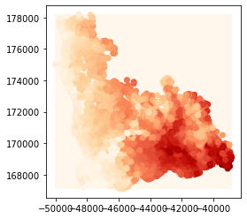

```python
# Add Boundaries
gdf_filt_n = gdf_filt.append(geopandas.GeoDataFrame({'geometry': [POLY], 'Z':0}))
# Plot
gdf_filt_n.plot(column='Z', cmap='OrRd')
```

##### Process Micromobility Routes

###### From WKB to Geometry

```python
df['geoRoute'] = df['route'].apply(lambda x: wkb.loads(x, hex=True))
df['r_i'] = df['geoRoute'].apply(lambda x: x[0])
df['r_f'] = df['geoRoute'].apply(lambda x: x[-1])
```

###### Limit Data to Matosinhos

```python
# Only routes that are exclusively in Matosinhos are considered
df['in_Matosinhos'] = df.geoRoute.apply(lambda x: poly.contains(x))
df_Matosinhos = df[df['in_Matosinhos'] == True]

# Data Loss
len(df), len(df_Matosinhos)
```

```
(80151, 50554)
```

###### From GPS coordinates to EPSG: 3763

```python
df_Matosinhos['r_i_EPSG'] = df_Matosinhos['r_i'].apply(lambda x: convert_coord_fromGPS(x.x, x.y))
df_Matosinhos['r_f_EPSG'] = df_Matosinhos['r_f'].apply(lambda x: convert_coord_fromGPS(x.x, x.y))
```

```python
pd.to_pickle(df_Matosinhos, "./df_Matosinhos.pkl")
```

##### Process Geographic Censos Data

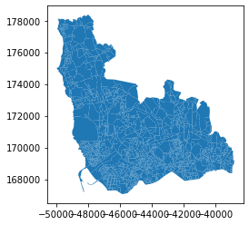

```python
folder = 'Censos_2011'
arr = os.listdir()
arr = os.listdir(folder)
cl_idx = [i.endswith('.shp') for i in arr]
arr_clean = [arr[idx] for idx, val  in enumerate(cl_idx) if val==True]
gdf = gpd.GeoDataFrame()
for i in arr_clean:
    gdf = gdf.append(gpd.GeoDataFrame.from_file(folder + '/' + i, driver='SHP'))

gdf = gdf.sort_values(['FR11','SEC11'], ascending = (True, True))
gdf.plot()
```

###### Statistical Sections

```python
clean_gdf = gdf[['DTMN11', 'FR11', 'SEC11','LUG11DESIG','geometry']]
clean_gdf = clean_gdf[0:0]
```

```python
unique_fr = gdf['FR11'].unique()
```

###### Agregate Subsections into Sections

```python
for fr in unique_fr:
    sec_index = 0
    temp = gdf.loc[gdf['FR11'] == fr]
    unique_sec = temp['SEC11'].unique()
    while  sec_index < len(unique_sec):
        temp2 = temp.loc[temp['SEC11'] == unique_sec[sec_index]]
        sec_boundary = temp2[['DTMN11', 'FR11', 'SEC11','LUG11DESIG','geometry']]
        sec = sec_boundary.dissolve(by='SEC11', as_index = False)
        clean_gdf.loc[len(clean_gdf)]=sec.loc[0]
        #clean_gdf.append(sec).reset_index()
        sec_index += 1
```

###### Plot 254 Sections

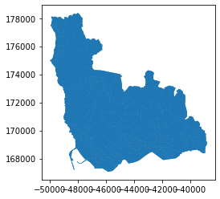

```python
clean_gdf.plot()
```

```python
clean_gdf['ID'] = clean_gdf['DTMN11'] + clean_gdf['FR11'] + clean_gdf['SEC11']
clean_gdf.head()
```

|  | DTMN11 | FR11 | SEC11 | LUG11DESIG | geometry | ID |
| --- | --- | --- | --- | --- | --- | --- |
| 0 | 1308 | 01 | 001 | Custóias | POLYGON ((-42840.718 171809.325, -42816.627 17... | 130801001 |
| 1 | 1308 | 01 | 002 | Custóias | POLYGON ((-42865.633 171186.539, -42871.866 17... | 130801002 |
| 2 | 1308 | 01 | 003 | Custóias | POLYGON ((-42940.050 170819.086, -42957.247 17... | 130801003 |
| 3 | 1308 | 01 | 004 | Custóias | POLYGON ((-43833.471 170251.655, -43840.631 17... | 130801004 |
| 4 | 1308 | 01 | 005 | Custóias | POLYGON ((-42976.069 170846.584, -42966.864 17... | 130801005 |

##### Associate Section to Point

###### Function to Find Section

```python
def findSection(my_point):
    section_id = ''
    for index, row in clean_gdf.iterrows():
        my_poligon = row['geometry']
        if my_poligon.contains(my_point):
            section_id = row['ID']
            break
    return section_id
# test function
findSection(geometry.Point(-48252.395911,169909.784902))
```

[output not shown]

```
'130805014'
```

###### Add Section to Cotas

```python
points = []
sections = []
for index, row in gdf_filt.iterrows():
    new_point = geometry.Point(row['X'], row['Y'])
    points.append(new_point)
    new_section = findSection(new_point)
    sections.append(new_section)
gdf_filt['Points'] = points
gdf_filt['Section'] = sections
```

```python
gdf_filt.head()
```

|  | geometry | X,Y | X | Y | Z | Points | Section |
| --- | --- | --- | --- | --- | --- | --- | --- |
| 759 | POINT Z (-41410.606 172766.196 53.580) | (-41410.60566479338, 172766.1959860094) | -41410.605665 | 172766.195986 | 53.58 | POINT (-41410.60566479338 172766.1959860094) | 130804003 |
| 761 | POINT Z (-41489.678 172879.117 47.970) | (-41489.67764606217, 172879.1174151989) | -41489.677646 | 172879.117415 | 47.97 | POINT (-41489.67764606217 172879.1174151989) | 130804003 |
| 763 | POINT Z (-41449.179 172754.483 52.580) | (-41449.17920392837, 172754.4828791071) | -41449.179204 | 172754.482879 | 52.58 | POINT (-41449.17920392837 172754.4828791071) | 130804003 |
| 765 | POINT Z (-41409.170 172469.832 51.670) | (-41409.16956793106, 172469.8318111786) | -41409.169568 | 172469.831811 | 51.67 | POINT (-41409.16956793106 172469.8318111786) | 130804003 |
| 767 | POINT Z (-40922.942 172008.176 41.080) | (-40922.94190827723, 172008.1758747094) | -40922.941908 | 172008.175875 | 41.08 | POINT (-40922.94190827723 172008.1758747094) | 130804004 |

###### Group Sections and Compute Mean Cota

```python
gdf_temp = gdf_filt.drop(columns=['geometry','X','Y', 'Points']).reset_index().drop(columns=['index'])
gdf_mean = gdf_temp.groupby(by = 'Section').mean().iloc[1: , :]
gdf_mean.head(10)
```

| Section | Z |
| --- | --- |
| 130801001 | 50.243782 |
| 130801002 | 57.688788 |
| 130801003 | 87.808276 |
| 130801004 | 71.639057 |
| 130801005 | 80.060625 |
| 130801006 | 88.502632 |
| 130801007 | 95.794000 |
| 130801008 | 93.052500 |
| 130801009 | 97.075758 |
| 130801010 | 74.193182 |

```python
pd.to_pickle(gdf_mean, "./section_cotas.pkl")
```

###### There are routes outside Matosinhos (really close to the border), let's get rid of them

```python
df_Matos = df_Matosinhos[(df_Matosinhos['Section_i'] != '') & (df_Matosinhos['Section_f'] != '')]
```

```python
pd.to_pickle(df_Matos, "./df_Matos.pkl")
```

###### Compute Delta Z for each Micromobility

```python
df_Matos_final = df_Matos.join(other=gdf_mean, on='Section_i')
df_Matos_final.rename(columns={'Z': 'Z_i'}, inplace=True)
df_Matos_final = df_Matos_final.join(other=gdf_mean, on='Section_f')
df_Matos_final.rename(columns={'Z': 'Z_f'}, inplace=True)
df_Matos_final['delta_z'] = df_Matos_final.Z_i - df_Matos_final.Z_f
```

```python
df_Matos_final['season'] = df_Matos_final['start_time'].apply(lambda x: get_season(x))
```

```python
pd.to_pickle(df_Matos_final, "./df_Matos_final.pkl")
df_Matos_final.head()
```

|  | vehicle_id | session_id | type | start_time | end_time | distance | saved_emissions | route | Label | duration | velocity | geoRoute | r_i | r_f | in_Matosinhos | r_i_EPSG | r_f_EPSG | Section_i | Section_f | Z_i | Z_f | delta_z |
| --- | --- | --- | --- | --- | --- | --- | --- | --- | --- | --- | --- | --- | --- | --- | --- | --- | --- | --- | --- | --- | --- | --- |
| 1 | 256 | 50c8da23-1aa9-4709-b00a-7f92edb582af | E-SCOOTER | 2019-05-30 16:43:39 | 2019-05-30 17:14:20 | 1064 | 97 | 010400000022000000010100000000000080E95D21C000... | 0 | 1841.0 | 0.577947 | (POINT (-8.683422088623047 41.17876815795898),... | POINT (-8.683422088623047 41.17876815795898) | POINT (-8.679533004760742 41.18567657470703) | True | (-46175.5201250829, 167877.23670758586) | (-45844.37688629917, 168642.41602328853) | 130806045 | 130806009 | 12.337500 | 34.047500 | -21.71 |
| 7 | 256 | c35b3152-b72b-4aa9-ba86-546ed2ae9d36 | E-SCOOTER | 2019-06-02 20:21:16 | 2019-06-02 20:42:31 | 3931 | 360 | 010400000071000000010100000000000020F76021C000... | 0 | 1275.0 | 3.083137 | (POINT (-8.689385414123535 41.17396926879883),... | POINT (-8.689385414123535 41.17396926879883) | POINT (-8.689436912536621 41.17376327514648) | True | (-46679.297535295336, 167347.46308352923) | (-46683.76522357475, 167324.61346891863) | 130806039 | 130806039 | 7.323333 | 7.323333 | 0.00 |
| 9 | 256 | df1186f5-9a6b-469e-a83e-d0c6deacb156 | E-SCOOTER | 2019-06-09 17:55:06 | 2019-06-09 18:03:41 | 450 | 41 | 0104000000AF000000010100000000000000767021C000... | 0 | 515.0 | 0.873786 | (POINT (-8.719650268554688 41.23117065429688),... | POINT (-8.719650268554688 41.23117065429688) | POINT (-8.719411849975586 41.22978973388672) | True | (-49176.106355827425, 173716.8443711543) | (-49157.15145997067, 173563.345686815) | 130807004 | 130807004 | 10.045455 | 10.045455 | 0.00 |
| 10 | 256 | 5a1584ba-2ef6-430d-a8fc-0ac6f4e49bcc | E-SCOOTER | 2019-06-05 09:46:18 | 2019-06-05 09:47:58 | 132 | 12 | 0104000000270000000101000000000000A0D65D21C000... | 0 | 100.0 | 1.320000 | (POINT (-8.68327808380127 41.182373046875), PO... | POINT (-8.68327808380127 41.182373046875) | POINT (-8.683309555053711 41.18245697021484) | True | (-46160.90568158518, 168277.51238524538) | (-46163.487290707315, 168286.8494505103) | 130806016 | 130806016 | 20.406667 | 20.406667 | 0.00 |
| 11 | 256 | b313e6ba-d69a-4953-a170-814bcb99b219 | E-SCOOTER | 2019-05-28 15:01:07 | 2019-05-28 15:17:10 | 4126 | 378 | 0104000000270000000101000000000000A0D65D21C000... | 0 | 963.0 | 4.284528 | (POINT (-8.68327808380127 41.182373046875), PO... | POINT (-8.68327808380127 41.182373046875) | POINT (-8.683309555053711 41.18245697021484) | True | (-46160.90568158518, 168277.51238524538) | (-46163.487290707315, 168286.8494505103) | 130806016 | 130806016 | 20.406667 | 20.406667 | 0.00 |

#### 3. Statement of Assumptions Made

##### Distance

The distance of each trip was analysed and notable outliers were found. The 5 highest values were removed since they had a higher order of magnitude when compared to the rest of the data: an upper boundary of 10Km was defined.

Also, we found that there are a lot of trips with residual distance, so we had to decide a threshold to filter them. Therefore, trips with a distance smaller than 25m were removed.

```python
# Plot Boxplot
fig, ax = plt.subplots(1,figsize=(7,7))
plt.tick_params(bottom=False, labelbottom=False)
sns.boxplot(width=0.4,
        data=all_data['distance'],
         palette=sns.color_palette("husl", 5),
        ax=ax)

ax.set_title('Boxplot of Distance')
ax.set_ylabel('Distance (m)')
```

[output not shown]

```python
#Analysis of highest values
df_sort = all_data.sort_values(['distance'], ascending = False)
df_sort['distance'].head(10)
```

[output not shown]

```python
df_sort = df_sort.loc[(df_sort['distance'] < 10000) & (df_sort['distance'] > 25)]
fig, ax = plt.subplots()
df_sort['distance'].hist(ax=ax)
ax.set_title('Histogram of Distance')
ax.set_xlabel('Distance (m)')
ax.set_ylabel('Counts')
```

[output not shown]

#### 4. Overview of Modelling Approaches Used

##### Recommendation Model

Goal: Model that predicts the likelihood of a user choosing between a bike, a scooter or an electric scooter, given the distance of the trip, the season of the year and terrain relief.

We checked for the occurrencies of each class (type of micromobility) and observed a big data imbalance, which will be dealt with subsampling of the data.

Usage:

1. Recomendation of type of micromobility in mobile application
2. Estimate utilization of each type by region

###### Process Data

```python
def process_data_classification(data, subsample=False, test_split=0.2, normalization = True, validation_split=0.2, random_st=np.random.RandomState(30), show_prints=True):

    if subsample:

        bikes = data.loc[data['Label'] == 2]
        scooter = data.loc[data['Label'] == 1]
        escooter = data.loc[data['Label'] == 0]

        bikes = bikes.sample(n=len(scooter), axis=0)
        escooter = escooter.sample(n=len(scooter), axis=0)
        data = pd.concat([bikes, scooter, escooter], ignore_index=True)

    if show_prints:
        print("\nNumber of samples: ", len(data))
        print(Counter(data['Label']))

    labels=data['Label']
    data=data[['distance', 'season', 'delta_z']]

    #Divide in train + test
    X_train, X_test, y_train, y_test = train_test_split(data, labels, shuffle=True, test_size=test_split, random_state=random_st)

    if normalization:
        scaler = StandardScaler()
        X_train = scaler.fit_transform(X_train) #normalize features
        X_test = scaler.transform(X_test)

    if show_prints:
        print("\nTrain size: ", len(X_train))

        print("Test size: ", len(X_test))

        print("\nTrain:")
        print(Counter(y_train))
        print("0 - {:.2f} %".format((Counter(y_train)[0.0]/(Counter(y_train)[0.0]+Counter(y_train)[1.0]+Counter(y_train)[2.0]))*100))
        print("1 - {:.2f} %".format((Counter(y_train)[1.0]/(Counter(y_train)[0.0]+Counter(y_train)[1.0]+Counter(y_train)[2.0]))*100))
        print("2 - {:.2f} %".format((Counter(y_train)[2.0]/(Counter(y_train)[0.0]+Counter(y_train)[1.0]+Counter(y_train)[2.0]))*100))

        print("\nTest:")
        print(Counter(y_test))
        print("0 - {:.2f} %".format((Counter(y_test)[0.0]/(Counter(y_test)[0.0]+Counter(y_test)[1.0]+Counter(y_test)[2.0]))*100))
        print("1 - {:.2f} %".format((Counter(y_test)[1.0]/(Counter(y_test)[0.0]+Counter(y_test)[1.0]+Counter(y_test)[2.0]))*100))
        print("2 - {:.2f} %".format((Counter(y_test)[2.0]/(Counter(y_test)[0.0]+Counter(y_test)[1.0]+Counter(y_test)[2.0]))*100))
        print()

        return X_train, X_test, y_train, y_test
```

```python
# Process data
X_train, X_test, y_train, y_test = process_data_classification(df[['distance', 'season', 'delta_z','Label']], subsample=True, test_split=0.2, normalization=True, validation_split=0.2,show_prints=True)

y_train = y_train.to_numpy().astype(int)
y_test = y_test.to_numpy().astype(int)
```

```
Number of samples:  696
Counter({2: 232, 1: 232, 0: 232})

Train size:  556
Test size:  140

Train:
Counter({2: 190, 0: 185, 1: 181})
0 - 33.27 %
1 - 32.55 %
2 - 34.17 %

Test:
Counter({1: 51, 0: 47, 2: 42})
0 - 33.57 %
1 - 36.43 %
2 - 30.00 %
```

###### Train Model

Parameter optimization with grid search and cross validation

```python
param_grid = {'C': [100,10, 1, .1, 0.01, 0.001,],
               'solver': ['newton-cg', 'liblinear', 'lbfgs'],
                 'max_iter': [100, 200, 1000]}

model = LogisticRegression(random_state=42)

grid = GridSearchCV(model, param_grid, n_jobs = -1, refit = False, verbose=1, return_train_score = True, scoring = {'accuracy'})
grid.fit(X_train, y_train)

results = pd.DataFrame(grid.cv_results_)

results = results.sort_values(by = ['mean_test_accuracy'], ascending = False)

best_results = results.iloc[0]

PARAMS = best_results['params']

print("Best params: ", PARAMS)

best_model = model.set_params(**PARAMS)
best_model.fit(X_train, y_train)
```

```
Fitting 5 folds for each of 54 candidates, totalling 270 fits
Best params:  {'C': 0.01, 'max_iter': 200, 'solver': 'lbfgs'}
```

```
LogisticRegression(C=0.01, max_iter=200, random_state=42)
```

##### Emissions Model

Goal: Model that predicts the saved emissions of a micromobility trip, given the set of features that describe the trip.

Usage:

1. Cash back in mobile application
2. Estimate total impact per region

###### Process Data

```python
X= df[['distance', 'delta_z']].to_numpy()
y = df['saved_emissions'].to_numpy()
```

###### Train Model

```python
def performance_evaluation(model, X_train, X_test, y_train, y_test, y_pred_train, y_pred_test):

    train_r2 = r2_score(y_train, y_pred_train)
    test_r2 = r2_score(y_test, y_pred_test)

    train_mae = mean_absolute_error(y_train, y_pred_train)
    test_mae = mean_absolute_error(y_test, y_pred_test)

    # estimate bias and variance
    mse, bias, var = bias_variance_decomp(model, X_train, y_train, X_test, y_test, loss='mse', num_rounds=200, random_seed=1)

    dif_train = y_train - y_pred_train

    train_fig = plt.figure()
    plt.scatter(y_pred_train, dif_train)
    plt.title('Train Residuals')
    plt.axhline(y=0, color='black', linestyle='--', lw=0.5)
    plt.xlabel('Predictions')
    plt.ylabel('Residuals')

    dif_test = y_test - y_pred_test
    test_fig = plt.figure()
    plt.scatter(y_pred_test, dif_test)
    plt.title('Test Residuals')
    plt.axhline(y=0, color='black', linestyle='--', lw=0.5)
    plt.xlabel('Predictions')
    plt.ylabel('Residuals')

    plt.close('all')

    return train_r2, test_r2, train_mae, test_mae, mse, bias, var, train_fig, test_fig
```

```python
from sklearn.model_selection import KFold

kf = KFold(n_splits=5)
kf.get_n_splits(X)

train_r2 = []
test_r2 = []
train_mae = []
test_mae = []
mse_=[]
bias_=[]
var_=[]
train_fig = []
test_fig = []

for train_index, test_index in kf.split(X):

    X_train, X_test = X[train_index], X[test_index]
    y_train, y_test = y[train_index], y[test_index]

    model = "Linear Regression"

    reg = LinearRegression()
    reg.fit(X_train, y_train)

    y_pred_train = reg.predict(X_train)
    y_pred_test = reg.predict(X_test)

    tr_r2, t_r2, tr_mae, t_mae, mse, bias, var, tr_fig, t_fig = performance_evaluation(reg, X_train, X_test, y_train, y_test, y_pred_train, y_pred_test)

    train_r2.append(tr_r2)
    test_r2.append(t_r2)
    train_mae.append(tr_mae)
    test_mae.append(t_mae)
    mse_.append(mse)
    bias_.append(bias)
    var_.append(var)
    train_fig.append(tr_fig)
    test_fig.append(t_fig)
```

#### 5. Evaluation and discussion of results and model performance

##### Recommendation Model

```python
def evaluate_model_multiclass(X_train, y_train, X_test, y_test, clf):

    n_classes=3

    y_pred_train = clf.predict(X_train)
    y_pred_test = clf.predict(X_test)

    train_f1 = f1_score(y_train, y_pred_train, average='macro')
    test_f1 = f1_score(y_test, y_pred_test, average='macro')

    accuracy_train = accuracy_score(y_train, y_pred_train)
    accuracy_test = accuracy_score(y_test, y_pred_test)

    train_cm = multilabel_confusion_matrix(y_train, y_pred_train)
    train_cm = list(train_cm)

    plt.close('all')

    plot_confusion_matrix(clf, X_train, y_train, cmap='YlGnBu')
    plot_confusion_matrix(clf, X_test, y_test, cmap='YlGnBu')

    print("\nTrain results:\nAccuracy={:.3f}\nF1={:.3f}\n".format(accuracy_train, train_f1))
    print("\nTest results:\nAccuracy={:.3f}\nF1={:.3f}\n".format(accuracy_test, test_f1))
```

```
Train results:
Accuracy=0.561
F1=0.522


Test results:
Accuracy=0.586
F1=0.544
```

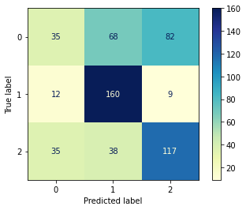

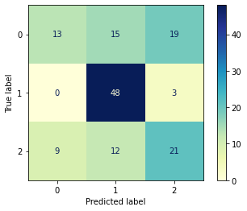

```python
evaluate_model_multiclass(X_train, y_train, X_test, y_test, best_model)
```

##### Emissions Model

```python
print("\nBias and Variance Trade-off:\nMean Square Error={:.3f}\nBias={:.3f}\nVariance={:.3f}\n".format(np.median(np.array(mse_)), np.median(np.array(bias_)), np.median(np.array(var_))))
print("\nTrain results:\nR2={:.3f}\nMean Absolute Error={:.3f}\n".format(np.median(np.array(train_r2)), np.median(np.array(train_mae))))
print("\nTest results:\nR2={:.3f}\nMean Absolute Error={:.3f}\n".format(np.median(np.array(test_r2)), np.median(np.array(test_mae))))
```

```
Bias and Variance Trade-off:
Mean Square Error=113.632
Bias=113.598
Variance=0.032


Train results:
R2=0.971
Mean Absolute Error=1.331


Test results:
R2=0.996
Mean Absolute Error=0.873
```

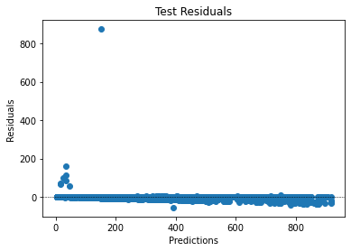

```python
#Show an example of the test residuals in one of the folds
test_fig[0]
```

#### 6. Model Interpretability and Fairness

##### Recommendation Model

To better understand what the model is using to predict the probabilities of each micromobility type, feature importance was accessed.

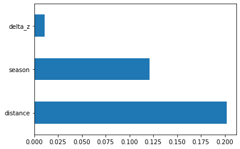

```python
features_names=['distance', 'season', 'delta_z']
pd.Series(abs(best_model.coef_[0]), index=features_names).nlargest(10).plot(kind='barh')
```

#### 7. Results Discussion

Recommendation Model

Emissions Model

#### 8. Results and Presentation Conclusions

##### Count Number of Bikes and Scooters

```python
frota = pd.DataFrame(df_Matos_final.groupby(['vehicle_id', 'type'])['vehicle_id'].count()).rename(columns={'vehicle_id': 'count'}).reset_index()
```

```python
frota.groupby('type').count()['count']
```

```
type
BIKE           27
E-SCOOTER    1442
SCOOTER        33
Name: count, dtype: int64
```

```python
df_Matos_final['season'] = df_Matos_final['start_time'].apply(lambda x: get_season(x))
```

##### Penetration Index

```python
df_Matos_ads = df_Matos_final[(df_Matos_final.type != 'BIKE') & (df_Matos_final.season != 0) & (df_Matos_final.season != 2)]
```

```python
df_Matos_ads
```

|  | vehicle_id | session_id | type | start_time | end_time | distance | saved_emissions | route | Label | duration | velocity | geoRoute | r_i | r_f | in_Matosinhos | r_i_EPSG | r_f_EPSG | Section_i | Section_f | Z_i | Z_f | delta_z | season |
| --- | --- | --- | --- | --- | --- | --- | --- | --- | --- | --- | --- | --- | --- | --- | --- | --- | --- | --- | --- | --- | --- | --- | --- |
| 47 | 512 | 2d1a87af-9f91-457f-afbe-1c209eb44290 | E-SCOOTER | 2019-07-03 15:36:25 | 2019-07-03 15:47:01 | 2216 | 203 | 0104000000300000000101000000000000000E6121C000... | 0 | 636.0 | 3.484277 | (POINT (-8.689559936523438 41.17346954345703),... | POINT (-8.689559936523438 41.17346954345703) | POINT (-8.68641471862793 41.18215179443359) | True | (-46694.29728357741, 167292.05822353245) | (-46424.23618028001, 168254.60926778615) | 130806039 | 130806019 | 7.323333 | 17.751667 | -10.428333 | 1 |
| 52 | 512 | f107a1c0-f555-4c43-bfa8-209368b52f7e | E-SCOOTER | 2019-06-21 17:33:38 | 2019-06-21 17:45:40 | 1464 | 134 | 010400000025000000010100000000000020A86021C000... | 0 | 722.0 | 2.027701 | (POINT (-8.688782691955566 41.17423248291016),... | POINT (-8.688782691955566 41.17423248291016) | POINT (-8.681719779968262 41.17419815063477) | True | (-46628.533992071876, 167376.37199847828) | (-46035.882485547794, 167368.7988741988) | 130806032 | 130806026 | 11.915000 | 19.568333 | -7.653333 | 1 |
| 54 | 512 | 3541ab94-4372-4137-b6e8-ffcd18fe2105 | E-SCOOTER | 2019-06-28 21:24:11 | 2019-06-28 21:31:40 | 2360 | 216 | 0104000000430000000101000000000000C0DA5621C000... | 0 | 449.0 | 5.256125 | (POINT (-8.669637680053711 41.18147659301758),... | POINT (-8.669637680053711 41.18147659301758) | POINT (-8.690085411071777 41.18174362182617) | True | (-45017.043870776084, 168170.80725681264) | (-46732.510891577556, 168211.24332233905) | 130810035 | 130806038 | 53.073750 | 11.583333 | 41.490417 | 1 |
| 60 | 512 | a986cbd9-c925-487b-934b-4f02c13c8514 | E-SCOOTER | 2019-06-20 14:22:36 | 2019-06-20 14:33:55 | 1837 | 168 | 0104000000370000000101000000000000E06B7021C000... | 0 | 679.0 | 2.705449 | (POINT (-8.719573020935059 41.2308235168457), ... | POINT (-8.719573020935059 41.2308235168457) | POINT (-8.719632148742676 41.23078536987305) | True | (-49169.88992790119, 173678.24788307768) | (-49174.87588111287, 173674.04475964254) | 130807004 | 130807004 | 10.045455 | 10.045455 | 0.000000 | 3 |
| 62 | 512 | 7d04900d-867e-42db-8324-2eae4f8b885a | E-SCOOTER | 2019-07-06 07:02:32 | 2019-07-06 07:10:49 | 1189 | 109 | 01040000001A0000000101000000000000409E5C21C000... | 0 | 497.0 | 2.392354 | (POINT (-8.68089485168457 41.180908203125), PO... | POINT (-8.68089485168457 41.180908203125) | POINT (-8.690460205078125 41.17971038818359) | True | (-45961.96863026584, 168113.5680190224) | (-46765.40402389436, 167985.63759176174) | 130806043 | 130806039 | 23.045000 | 7.323333 | 15.721667 | 1 |
| ... | ... | ... | ... | ... | ... | ... | ... | ... | ... | ... | ... | ... | ... | ... | ... | ... | ... | ... | ... | ... | ... | ... | ... |
| 158305 | 2303 | 85954bbe-a41e-4249-acac-a95eb0cf7a11 | E-SCOOTER | 2020-01-13 12:51:46 | 2020-01-13 13:00:19 | 1252 | 114 | 010400000026000000010100000000000060505E21C000... | 0 | 513.0 | 2.440546 | (POINT (-8.684206962585449 41.18455123901367),... | POINT (-8.684206962585449 41.18455123901367) | POINT (-8.676690101623535 41.17974090576172) | True | (-46237.30958398703, 168519.9115697089) | (-45609.97793205218, 167981.71776102195) | 130806009 | 130806024 | 34.047500 | 24.020000 | 10.027500 | 3 |
| 158308 | 2303 | ab03d15e-8cda-4931-9c2f-b1bfdd09781c | E-SCOOTER | 2020-01-11 19:39:50 | 2020-01-11 19:56:52 | 1961 | 180 | 01040000003E000000010100000000000020EE6121C000... | 0 | 1022.0 | 1.918787 | (POINT (-8.691269874572754 41.17687225341797),... | POINT (-8.691269874572754 41.17687225341797) | POINT (-8.681483268737793 41.17273330688477) | True | (-46835.36253568048, 167670.8752857348) | (-46017.0610144116, 167205.99124454623) | 130806041 | 130806026 | 7.917500 | 19.568333 | -11.650833 | 3 |
| 158310 | 2303 | ff4009d2-3478-4a38-9976-dea0eaf148f1 | E-SCOOTER | 2020-01-13 13:07:28 | 2020-01-13 13:11:49 | 766 | 70 | 010400000019000000010100000000000080895A21C000... | 0 | 261.0 | 2.934866 | (POINT (-8.676830291748047 41.17976760864258),... | POINT (-8.676830291748047 41.17976760864258) | POINT (-8.677945137023926 41.18216705322266) | True | (-45621.722295249936, 167984.75682158244) | (-45713.59673926898, 168251.819641799) | 130806024 | 130806012 | 24.020000 | 29.283077 | -5.263077 | 3 |
| 158313 | 2303 | f68a33a0-e47a-4d31-baae-aa774c615653 | E-SCOOTER | 2020-01-13 13:53:41 | 2020-01-13 14:04:25 | 1091 | 100 | 01040000001C000000010100000000000060225B21C000... | 0 | 644.0 | 1.694099 | (POINT (-8.677996635437012 41.18208312988281),... | POINT (-8.677996635437012 41.18208312988281) | POINT (-8.679963111877441 41.18256378173828) | True | (-45717.97600840252, 168242.52633138036) | (-45882.63524085214, 168296.9417076515) | 130806012 | 130806012 | 29.283077 | 29.283077 | 0.000000 | 3 |
| 158316 | 2303 | 5bc9e954-c0ad-40fa-8431-ba967c342ec6 | E-SCOOTER | 2020-01-11 18:40:11 | 2020-01-11 19:04:23 | 1891 | 173 | 01040000003B000000010100000000000080A05C21C000... | 0 | 1452.0 | 1.302342 | (POINT (-8.680912017822266 41.17307281494141),... | POINT (-8.680912017822266 41.17307281494141) | POINT (-8.691269874572754 41.17687225341797) | True | (-45968.886775558116, 167243.39441397725) | (-46835.36253568048, 167670.8752857348) | 130806026 | 130806041 | 19.568333 | 7.917500 | 11.650833 | 3 |

17117 rows × 23 columns

```python
len(df_Matos_ads.start_time.apply(lambda x: x.strftime('%Y-%m-%d')).unique())
```

```
85
```

```python
df_Matos_ads.iloc[0].start_time.strftime('%Y-%m-%d')
```

```
'2019-07-03'
```

```python
df_1 = df_Matos_ads[df_Matos_ads.season == 1]
df_3 = df_Matos_ads[df_Matos_ads.season == 3]
n_days_df1 = len(df_1.start_time.apply(lambda x: x.strftime('%Y-%m-%d')).unique())
n_days_df3 = len(df_3.start_time.apply(lambda x: x.strftime('%Y-%m-%d')).unique())
n_days_df1, n_days_df3
```

```
(52, 33)
```

##### Flow per day for each Section

```python
df_1 = df_1.groupby('Section_i').count()['vehicle_id']/n_days_df1
```

[output not shown]

```python
df_3 = df_3.groupby('Section_i').count()['vehicle_id']/n_days_df3
df_3
```

[output not shown]

[output cut: 207 more lines]

```python
pd.to_pickle(df_1, "./season1_micro_flow_per_day.pkl")
pd.to_pickle(df_3, "./season3_micro_flow_per_day.pkl")
```

##### Compute Final Taxa de Adesão

```python
season_1_flows_final = pd.read_pickle("./season_1_flows_final.pkl")
season_3_flows_final = pd.read_pickle("./season_3_flows_final.pkl")
```

```python
df_1 = df_1.reset_index().rename(columns={'Section_i':'s1'})
df_3 = df_3.reset_index().rename(columns={'Section_i':'s1'})
```

```python
df_1.s1=df_1.s1.astype(int)
df_1 = df_1.set_index('s1')
df_3.s1=df_3.s1.astype(int)
df_3 = df_3.set_index('s1')
```

```python
season_1_flows_final = season_1_flows_final[['countFlowsPerDay','s1']]
season_3_flows_final = season_3_flows_final[['countFlowsPerDay','s1']]
```

```python
season_1 = season_1_flows_final.join(df_1, how='left', on='s1').rename(columns={'vehicle_id':'countMicroFlowsPerDay'}).set_index('s1')
season_3 = season_3_flows_final.join(df_3, how='left', on='s1').rename(columns={'vehicle_id':'countMicroFlowsPerDay'}).set_index('s1')
```

```python
season_1['indexPenetration'] = season_3.countMicroFlowsPerDay / season_1.countFlowsPerDay
season_1 = season_1.fillna(0)
season_3['indexPenetration'] = season_3.countMicroFlowsPerDay / season_3.countFlowsPerDay
season_3 = season_3.fillna(0)
```

```python
season_1 = season_1.sort_values(by='indexPenetration', ascending=False)
season_3 = season_3.sort_values(by='indexPenetration', ascending=False)
```

```python
pd.to_pickle(season_1, "./season1_penetration.pkl")
pd.to_pickle(season_3, "./season3_penetration.pkl")
```

##### Current Bikes Pickup Points

```python
sections_polygons = clean_gdf.set_index('ID')[['geometry']]
```

```python
sections_polygons.drop_duplicates(inplace=True)
len(sections_polygons)
```

```
254
```

```python
df_bikes = df_Matos_final[df_Matos_final.type == 'BIKE']
df_bikes['pickUp'] = df_bikes.r_i_EPSG.apply(lambda x: geometry.Point(x))
```

```python
df_plot = pd.concat([df_bikes.pickUp, sections_polygons.geometry], axis=0)
```

```python
gpd = geopandas.GeoDataFrame(data=df_plot)
```

```python
gpd = gpd.rename(columns = {0:'geometry'})
gpd['Z'] = gpd.geometry.apply(lambda x: 1 if type(x) == shapely.geometry.point.Point else 0)
```

```python
gpd.head()
```

|  | geometry | Z |
| --- | --- | --- |
| 432 | POINT (-45937.494 167170.326) | 1 |
| 433 | POINT (-45929.937 167163.076) | 1 |
| 439 | POINT (-45936.611 167170.744) | 1 |
| 440 | POINT (-45933.274 167205.040) | 1 |
| 441 | POINT (-45937.750 167205.916) | 1 |

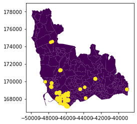

```python
gpd.plot('Z')
```

##### Current Flow per Day of Micromobility per Section

```python
df_flows_micro = df_1[['vehicle_id']].rename(columns={'vehicle_id': 'Z'}).reset_index()
df_flows_micro.s1 = df_flows_micro.s1.apply(lambda x: str(int(x)))
df_flows_micro = df_flows_micro.join(sections_polygons, how='left', on='s1').set_index('s1')
```

```python
df_fl_plots = geopandas.GeoDataFrame(df_flows_micro)
```

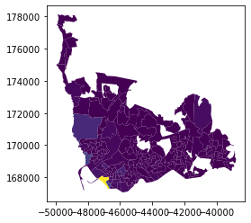

```python
df_fl_plots.plot('Z')
```

```python
len(df_1)
```

```
220
```

##### Compute Total Current Emissions per Season

```python
df_Matos_ads.groupby('season').saved_emissions.sum().loc[1]
svd_emissions_perDay_1 = df_Matos_ads.groupby('season').saved_emissions.sum().loc[1] / n_days_df1
svd_emissions_perDay_3 = df_Matos_ads.groupby('season').saved_emissions.sum().loc[3] / n_days_df3
```

```python
svd_emissions_perDay_1, svd_emissions_perDay_3
```

```
(44024.903846153844, 19923.515151515152)
```

### II Prescriptive component

#### 1. Exploratory Data Analysis

##### Mobility Flows

After observing the NOS mobility flows dataset, we chose the variables that seemed the most relevant and could be related to other datasets:

1. Geographic code of origin and destiny
2. Date of the flow in the format YYYY-MM-DD with hours

With this we accessed the mobility flow between localities of Matosinhos.

```python
#NOS Mobility Flows

query = """
SELECT substring(Codigo_Seccao_A, 3, 9) as origin,
    substring(Codigo_Seccao_B, 3, 9) as destiny,
    dia as day,
    substring(Formato_Transicao,1,19) as schedule,

FROM `eurekathon-hub.NOS.mobility_flows`
WHERE  substring(Formato_Transicao,1,10) between '2018-01-01' and '2021-11-13'
order BY (substring(Codigo_Seccao_A, 3, 9))
"""

dfBC = (
    bqclient.query(query)
    .result()
    .to_dataframe()
)
dfBC.head(5)
```

|  | origin | destiny | day | schedule |
| --- | --- | --- | --- | --- |
| 0 | 130801001 | 130802001 | 2021-01-30 00:00:00+00:00 | 2021-01-01 19:00:00 |
| 1 | 130801001 | 130804002 | 2021-01-30 00:00:00+00:00 | 2021-01-01 22:00:00 |
| 2 | 130801001 | 130805003 | 2021-01-30 00:00:00+00:00 | 2021-01-01 16:00:00 |
| 3 | 130801001 | 130801004 | 2019-03-26 00:00:00+00:00 | 2019-03-01 17:00:00 |
| 4 | 130801001 | 130801009 | 2019-03-26 00:00:00+00:00 | 2019-03-01 15:00:00 |

Considering the data available in the table above, the selection of the relevant variables in the table driving times were accessed:

1. Driving_times origin and destiny code
2. Linear Distance
3. Driving Distance
4. Driving time

```python
#GEO Driving Times
query = """
SELECT * FROM eurekathon-hub.GEO.driving_times
"""

df = (
    bqclient.query(query)
    .result()
    .to_dataframe()
)
df_distanceBetweenSections = df.drop(['row', 'lat_s1','lon_s1', 'lat_s2','lon_s2'], axis=1)
df_distanceBetweenSections.sort_values(by = 's2')
df_distanceBetweenSections.head(5)
```

|  | s1 | s2 | lin_dist | driving_time | driving_distance |
| --- | --- | --- | --- | --- | --- |
| 0 | 130806016 | 130806006 | 657.047053 | 57.717162 | 1179.454653 |
| 1 | 130806017 | 130806006 | 706.675523 | 62.076689 | 1268.541925 |
| 2 | 130806018 | 130806006 | 623.113048 | 54.736288 | 1118.540263 |
| 3 | 130806019 | 130806006 | 764.363320 | 67.144174 | 1372.096367 |
| 4 | 130806020 | 130806006 | 1023.110065 | 89.873334 | 1836.568509 |

##### Censos Analysis

One of our solutions to improve microbility is to evaluate the localities that could benefit more of an increase in this type of resources and where there is a higher probability of converting more users into travelling by scooters or bikes.

In order to do that, we scored each locality based on features that we manually selected of the 2011 Censos Dataset, analysing each feature correlation to the potential of having higher penetration of micromobility.

The scores attributed to each features is bellow. The assumptions that had to be taken into account are in the next section.

```python
score = pd.read_excel('Censos_2011/Pontuações_Zonas.xlsx')
score.head(5)
```

|  | CÓDIGO;DESIGNAÇÃO;METAINFORMAÇÃO | Score |
| --- | --- | --- |
| 0 | ano;Ano do recenseamento; | 0 |
| 1 | geo_cod;Codigo da geografia utilizada; | Index |
| 2 | geo_cod_dsg;Descrição da geografia utilizada; | 0 |
| 3 | nivel;Nivel de desagregação da linha; | 0 |
| 4 | nivel_dsg;Descrição do nivel de desagregação d... | 0 |

```python
censos = pd.read_csv('Censos_2011/censosClean.csv', sep=";")
censos.head(5)
```

|  | GEO_COD | N_ALOJAMENTOS_RES_HABITUAL | N_RES_HABITUAL_ESTAC_1 | N_RES_HABITUAL_ESTAC_2 | N_RES_HABITUAL_ESTAC_3 | N_FAMILIAS_CLASSICAS_1OU2_PESS | N_FAMILIAS_CLASSICAS_3OU4_PESS | N_FAMILIAS_CLASSICAS_NPES65 | N_NUCLEOS_FILH_INF_6ANOS | N_NUCLEOS_FILH_INF_15ANOS | N_NUCLEOS_FILH_MAIS_15ANOS | N_INDIVIDUOS_RESIDENT | N_IND_RESID_ESTUD_MUN_RESID | N_IND_RESID_TRAB_MUN_RESID |
| --- | --- | --- | --- | --- | --- | --- | --- | --- | --- | --- | --- | --- | --- | --- |
| 0 | '130801001 | 230 | 50 | 26 | 17 | 131 | 78 | 85 | 22 | 53 | 77 | 606 | 70 | 160 |
| 1 | '130801002 | 203 | 64 | 24 | 9 | 99 | 89 | 72 | 24 | 47 | 79 | 547 | 83 | 131 |
| 2 | '130801003 | 217 | 86 | 34 | 16 | 110 | 93 | 83 | 21 | 56 | 77 | 1171 | 195 | 467 |
| 3 | 130801004 | 264 | 126 | 38 | 5 | 138 | 109 | 94 | 42 | 72 | 71 | 676 | 99 | 164 |
| 4 | '130801005 | 273 | 176 | 48 | 20 | 73 | 189 | 48 | 48 | 113 | 111 | 813 | 164 | 241 |

#### 2. Statement of Assumptions Made

##### Mobility Flows

We assumed as flows of a locality only the commutes trips that had origin in that locality, and we did not consider those which had the locality in question as a destiny, assuming that the people who travel into a location also travel out of it, and that we could simplificate our analysis by only looking at the origin zone. Besides that, only the initial and final Z value of points was considered in delta computation

##### Censos Analysis

We assumed a scale from -3 to 3, with more positive scores indicating characteristics that suggest that those localities have a more suitable profile for microbility.

For this, we also assumed some of the characteristics of what we believe is a typical user of scooters or bikes, for example, younger people, without children, and that live in the same parish that they work/study at.

For instance, a positive score was given for the variable 'number of families with 1 or 2 people' and a negative one for 'number of families with 3 to 4 people'.

After deciding the score of each variable of interest, we multiplied this score for the number of occurrences in each locality. In the end we summed all the scores and obtained a final locality score.

##### Presciptive Model

For a first set of penetration scores, it was set to 5%, considering that this would be the interest of population in a first implementation. Therefore, the best region had a 5% penetration rate, and all lower regions were scaled from 0-5%.

#### 3. Data Processing

##### Mobility Flows

```python
#Remove hours and converting to datetime
dfBC['schedule']=dfBC['schedule'].apply(lambda x: datetime.datetime.strptime(x[:10], "%Y-%m-%d"))
```

```python
#In order to analyse how the time of the year affects the mobility flows,
#we classifed each flow based on the season when it ocurred
dfBC['season'] = dfBC['schedule'].apply(lambda x: get_season(x))
```

```python
dfBC.head(5)
```

|  | origin | destiny | day | schedule | season |
| --- | --- | --- | --- | --- | --- |
| 0 | 130801001 | 130802001 | 2021-01-30 00:00:00+00:00 | 2021-01-01 | 3 |
| 1 | 130801001 | 130804002 | 2021-01-30 00:00:00+00:00 | 2021-01-01 | 3 |
| 2 | 130801001 | 130805003 | 2021-01-30 00:00:00+00:00 | 2021-01-01 | 3 |
| 3 | 130801001 | 130801004 | 2019-03-26 00:00:00+00:00 | 2019-03-01 | 3 |
| 4 | 130801001 | 130801009 | 2019-03-26 00:00:00+00:00 | 2019-03-01 | 3 |

```python
#Group the flow count by season, origin and destiny
dfBCorganized = dfBC.groupby(['season','origin', 'destiny']).size()

#Unstack the indices
dfBCorganizedunstack = dfBCorganized.to_frame()
dfBCorganizedunstack = dfBCorganizedunstack.reset_index()

#Changing the columns' names, so they match the columns of the driving times dataset
dfBCorganizedunstack = dfBCorganizedunstack.rename(columns={0: 'countFlows', 'origin':'s1', 'destiny':'s2'})

#Estimation of daily flow, considering that 1 season has 90 days
dfBCorganizedunstack['countFlowsPerDay'] = dfBCorganizedunstack['countFlows']/90

dfBCorganizedunstack.head(5)
```

|  | season | s1 | s2 | countFlows | countFlowsPerDay |
| --- | --- | --- | --- | --- | --- |
| 0 | 1 | 130801001 | 130801001 | 4826 | 53.622222 |
| 1 | 1 | 130801001 | 130801002 | 2970 | 33.000000 |
| 2 | 1 | 130801001 | 130801003 | 2936 | 32.622222 |
| 3 | 1 | 130801001 | 130801004 | 2618 | 29.088889 |
| 4 | 1 | 130801001 | 130801005 | 2809 | 31.211111 |

Merging Datasets

```python
dfBCorganizedunstack['s1']=dfBCorganizedunstack['s1'].astype(int)
dfBCorganizedunstack['s2']=dfBCorganizedunstack['s2'].astype(int)

#Merging both datasets, based on the origin and destination
new_dfBC = pd.merge(df_distanceBetweenSections, dfBCorganizedunstack, on=['s1','s2'], how="right")

#Droping the NaN values (which are not notable, only 7 rows)
new_dfBC = new_dfBC.dropna()

#Calculus of the total number of kms in trips per locality of origin
new_dfBC['total_distance_per_origin']=new_dfBC['driving_distance']*new_dfBC['countFlowsPerDay']

new_dfBC.head(5)
```

|  | s1 | s2 | lin_dist | driving_time | driving_distance | season | countFlows | countFlowsPerDay | total_distance_per_origin |
| --- | --- | --- | --- | --- | --- | --- | --- | --- | --- |
| 1 | 130801001 | 130801002 | 816.536848 | 71.727267 | 1465.752232 | 1 | 2970 | 33.000000 | 48369.823645 |
| 2 | 130801001 | 130801003 | 1332.333623 | 117.036542 | 2391.650769 | 1 | 2936 | 32.622222 | 78020.962862 |
| 3 | 130801001 | 130801004 | 1795.956877 | 157.762725 | 3223.893454 | 1 | 2618 | 29.088889 | 93779.478480 |
| 4 | 130801001 | 130801005 | 1502.427787 | 131.978170 | 2696.984082 | 1 | 2809 | 31.211111 | 84175.869833 |
| 5 | 130801001 | 130801006 | 1874.005076 | 164.618734 | 3363.996528 | 1 | 2338 | 25.977778 | 87389.154242 |

```python
#Group variables by locality of origin
grouped_df = pd.DataFrame(new_dfBC.groupby(['season','s1'])['total_distance_per_origin'].sum())
grouped2_df = pd.DataFrame(new_dfBC.groupby(['season','s1'])['countFlowsPerDay'].sum())

#Merge both dataframes and calculate the average weighted distance by number of flows
all_grouped=pd.merge(grouped_df, grouped2_df, left_index=True, right_index=True)
all_grouped['dist_weightedAvgByNFlow'] = all_grouped['total_distance_per_origin']/all_grouped['countFlowsPerDay']
all_grouped.head(5)
```

| season | s1 | total_distance_per_origin | countFlowsPerDay | dist_weightedAvgByNFlow |
| --- | --- | --- | --- | --- |
| 1 | 130801001 | 2.444504e+06 | 1054.355556 | 2318.481440 |
|  | 130801002 | 9.255148e+05 | 505.700000 | 1830.165632 |
|  | 130801003 | 1.558486e+06 | 894.200000 | 1742.883133 |
|  | 130801004 | 1.440805e+06 | 856.944444 | 1681.328729 |
|  | 130801005 | 6.655385e+05 | 506.111111 | 1315.004716 |

##### Censos Analysis

Data processing to attritute to each feature the score considered appropriate

```python
censos['GEO_COD']=censos['GEO_COD'].apply(lambda x: x[1:])

censos = censos.set_index('GEO_COD')
```

```python
score['CÓDIGO;DESIGNAÇÃO;METAINFORMAÇÃO']=score['CÓDIGO;DESIGNAÇÃO;METAINFORMAÇÃO'].apply(lambda x: str(x).split(";",1)[0])

#Droping first and last two rows, without information
score = score.drop([0,1, 127,128])
#Removing scores equal to zero, which represent variables in the censos that we didn't consider relevant
score = score[score.Score != 0]
```

```python
score_final=pd.DataFrame()
for i, column in enumerate(censos.columns):
    #Obtaining the score of each of the variables of the censos
    row=score.loc[score['CÓDIGO;DESIGNAÇÃO;METAINFORMAÇÃO']==column.lower()]
    #Multiplying the score for the number of ocurrences
    score_final[column]=censos[column].apply(lambda x: x*row['Score'].item())
```

```python
#Adding the final geographic score to the dataframe
score_final['Geo Score'] = score_final.sum(axis=1)
score_final.head(5)
```

| GEO_COD | N_ALOJAMENTOS_RES_HABITUAL | N_RES_HABITUAL_ESTAC_1 | N_RES_HABITUAL_ESTAC_2 | N_RES_HABITUAL_ESTAC_3 | N_FAMILIAS_CLASSICAS_1OU2_PESS | N_FAMILIAS_CLASSICAS_3OU4_PESS | N_FAMILIAS_CLASSICAS_NPES65 | N_NUCLEOS_FILH_INF_6ANOS | N_NUCLEOS_FILH_INF_15ANOS | N_NUCLEOS_FILH_MAIS_15ANOS | N_INDIVIDUOS_RESIDENT | N_IND_RESID_ESTUD_MUN_RESID | N_IND_RESID_TRAB_MUN_RESID | Geo Score |
| --- | --- | --- | --- | --- | --- | --- | --- | --- | --- | --- | --- | --- | --- | --- |
| 130801001 | 230 | -50 | -52 | -51 | 262 | -78 | -170 | -44 | -53 | 154 | 606 | 210 | 480 | 1444 |
| 130801002 | 203 | -64 | -48 | -27 | 198 | -89 | -144 | -48 | -47 | 158 | 547 | 249 | 393 | 1281 |
| 130801003 | 217 | -86 | -68 | -48 | 220 | -93 | -166 | -42 | -56 | 154 | 1171 | 585 | 1401 | 3189 |
| 30801004 | 264 | -126 | -76 | -15 | 276 | -109 | -188 | -84 | -72 | 142 | 676 | 297 | 492 | 1477 |
| 130801005 | 273 | -176 | -96 | -60 | 146 | -189 | -96 | -96 | -113 | 222 | 813 | 492 | 723 | 1843 |

##### Presciptive Model

```python
scores1_flows_final = pd.read_pickle('season_1_flows_final.pkl').set_index('s1')[['countFlowsPerDay']]
season_1_flows_with_prob = pd.read_pickle('season_1_flows_with_prob.pkl')
```

```python
season_1_flows_with_prob_final = season_1_flows_with_prob[['s1','countFlowsPerDay', 'dist_weightedAvgByNFlow', 'delta_z_weightedAvgByNFlow', 'bikes', 'scooter', 'emissions']]
```

```python
season_1_flows_with_prob_final = season_1_flows_with_prob_final.rename(columns=
                                                                      {'s1': 'Section',
                                                                      'countFlowsPerDay': 'N_Flows',
                                                                      'dist_weightedAvgByNFlow': 'Wgt_Avg_Dist',
                                                                      'delta_z_weightedAvgByNFlow': 'Wgt_Avg_Z',
                                                                      'bikes': 'Prob_bikes',
                                                                      'scooter':'Prob_scooters',
                                                                      'emissions': 'CO2_PerTrip'})
```

```python
season_1_flows_with_prob_final.Section = season_1_flows_with_prob_final.Section.apply(lambda x: str(int(x)))
season_1_flows_with_prob_final
```

|  | Section | N_Flows | Wgt_Avg_Dist | Wgt_Avg_Z | Prob_bikes | Prob_scooters | CO2_PerTrip |
| --- | --- | --- | --- | --- | --- | --- | --- |
| 0 | 130801001 | 1054.355556 | 2318.481440 | -11.166578 | 0.5 | 0.5 | 212.793403 |
| 1 | 130801002 | 505.700000 | 1830.165632 | -18.134204 | 0.5 | 0.5 | 168.041240 |
| 2 | 130801003 | 894.200000 | 1742.883133 | 11.815976 | 0.5 | 0.5 | 159.975273 |
| 3 | 130801004 | 856.944444 | 1681.328729 | 4.596295 | 0.5 | 0.5 | 154.347657 |
| 4 | 130801005 | 506.111111 | 1315.004716 | 2.415391 | 0.5 | 0.5 | 120.769016 |
| ... | ... | ... | ... | ... | ... | ... | ... |
| 245 | 130810035 | 349.577778 | 902.523204 | -5.849404 | 0.5 | 0.5 | 82.971860 |
| 246 | 130810036 | 330.088889 | 755.045497 | -8.153496 | 0.5 | 0.5 | 69.456555 |
| 247 | 130810037 | 347.755556 | 818.274776 | 4.401048 | 0.5 | 0.5 | 75.226280 |
| 248 | 130810038 | 148.588889 | 723.850885 | 0.479832 | 0.5 | 0.5 | 66.578232 |
| 249 | 130810039 | 76.433333 | 434.795818 | 12.587706 | 0.5 | 0.5 | 40.052707 |

250 rows × 7 columns

```python
scores_censos = pd.DataFrame(pd.read_pickle('censos_final.pkl'))
scores_censos = scores_censos.reset_index()
scores_censos = scores_censos.rename(columns=
                                              {'GEO_COD': 'Section',
                                              'Geo Score': 'ScoreCensos'})
scores_censos.Section = scores_censos.Section.apply(lambda x: str(int(x)))
#scores_censos.Section.iloc[3] = '130801004'
#pd.to_pickle(scores_censos, './scores_censos.pkl')
```

```python
df_fullData = season_1_flows_with_prob_final.join(scores_censos.set_index('Section'), on='Section')
pd.to_pickle(df_fullData, './df_fullData.pkl')
df_fullData
```

|  | Section | N_Flows | Wgt_Avg_Dist | Wgt_Avg_Z | Prob_bikes | Prob_scooters | CO2_PerTrip | ScoreCensos |
| --- | --- | --- | --- | --- | --- | --- | --- | --- |
| 0 | 130801001 | 1054.355556 | 2318.481440 | -11.166578 | 0.5 | 0.5 | 212.793403 | 1444 |
| 1 | 130801002 | 505.700000 | 1830.165632 | -18.134204 | 0.5 | 0.5 | 168.041240 | 1281 |
| 2 | 130801003 | 894.200000 | 1742.883133 | 11.815976 | 0.5 | 0.5 | 159.975273 | 3189 |
| 3 | 130801004 | 856.944444 | 1681.328729 | 4.596295 | 0.5 | 0.5 | 154.347657 | 1477 |
| 4 | 130801005 | 506.111111 | 1315.004716 | 2.415391 | 0.5 | 0.5 | 120.769016 | 1843 |
| ... | ... | ... | ... | ... | ... | ... | ... | ... |
| 245 | 130810035 | 349.577778 | 902.523204 | -5.849404 | 0.5 | 0.5 | 82.971860 | 1142 |
| 246 | 130810036 | 330.088889 | 755.045497 | -8.153496 | 0.5 | 0.5 | 69.456555 | 1867 |
| 247 | 130810037 | 347.755556 | 818.274776 | 4.401048 | 0.5 | 0.5 | 75.226280 | 1386 |
| 248 | 130810038 | 148.588889 | 723.850885 | 0.479832 | 0.5 | 0.5 | 66.578232 | 1513 |
| 249 | 130810039 | 76.433333 | 434.795818 | 12.587706 | 0.5 | 0.5 | 40.052707 | 1572 |

250 rows × 8 columns

```python
#standardize
maxs = [df_fullData['ScoreCensos'].max(),df_fullData['Wgt_Avg_Dist'].max(),df_fullData['Wgt_Avg_Z'].max()]
mins = [df_fullData['ScoreCensos'].min(),df_fullData['Wgt_Avg_Dist'].min(),df_fullData['Wgt_Avg_Z'].min()]

def standardizer(df, column, maxs, mins, std_max, std_min):
    df[column] = df[column].apply(lambda x: (x - mins)/(maxs- mins) * (std_max-std_min) + std_min)

standardizer(df_fullData, 'ScoreCensos', maxs[0], mins[0], 1, 0)
standardizer(df_fullData, 'Wgt_Avg_Dist', maxs[1], mins[1], 1, 0)
standardizer(df_fullData, 'Wgt_Avg_Z', maxs[2], mins[2], 1, 0)
df_fullData
```

|  | Section | N_Flows | Wgt_Avg_Dist | Wgt_Avg_Z | Prob_bikes | Prob_scooters | CO2_PerTrip | ScoreCensos |
| --- | --- | --- | --- | --- | --- | --- | --- | --- |
| 0 | 130801001 | 1054.355556 | 0.431001 | 0.401903 | 0.5 | 0.5 | 212.793403 | 0.338485 |
| 1 | 130801002 | 505.700000 | 0.327245 | 0.273893 | 0.5 | 0.5 | 168.041240 | 0.277045 |
| 2 | 130801003 | 894.200000 | 0.308699 | 0.824143 | 0.5 | 0.5 | 159.975273 | 0.996231 |
| 3 | 130801004 | 856.944444 | 0.295620 | 0.691501 | 0.5 | 0.5 | 154.347657 | 0.350923 |
| 4 | 130801005 | 506.111111 | 0.217785 | 0.651434 | 0.5 | 0.5 | 120.769016 | 0.488881 |
| ... | ... | ... | ... | ... | ... | ... | ... | ... |
| 245 | 130810035 | 349.577778 | 0.130141 | 0.499591 | 0.5 | 0.5 | 82.971860 | 0.224651 |
| 246 | 130810036 | 330.088889 | 0.098806 | 0.457260 | 0.5 | 0.5 | 69.456555 | 0.497927 |
| 247 | 130810037 | 347.755556 | 0.112241 | 0.687914 | 0.5 | 0.5 | 75.226280 | 0.316623 |
| 248 | 130810038 | 148.588889 | 0.092178 | 0.615873 | 0.5 | 0.5 | 66.578232 | 0.364493 |
| 249 | 130810039 | 76.433333 | 0.030760 | 0.838321 | 0.5 | 0.5 | 40.052707 | 0.386732 |

250 rows × 8 columns

```python
# Penetration Probability
df_fullData['Prob_penetration'] = (df_fullData['ScoreCensos'] + df_fullData['Wgt_Avg_Dist'] + df_fullData['Wgt_Avg_Z'])/3
df_fullData.sort_values(by='Prob_penetration')
pd.to_pickle(df_fullData, 'df_fullData.pkl')
df_fullData
```

|  | Section | N_Flows | Wgt_Avg_Dist | Wgt_Avg_Z | Prob_bikes | Prob_scooters | CO2_PerTrip | ScoreCensos | Prob_penetration |
| --- | --- | --- | --- | --- | --- | --- | --- | --- | --- |
| 0 | 130801001 | 1054.355556 | 0.431001 | 0.401903 | 0.5 | 0.5 | 212.793403 | 0.338485 | 0.390463 |
| 1 | 130801002 | 505.700000 | 0.327245 | 0.273893 | 0.5 | 0.5 | 168.041240 | 0.277045 | 0.292727 |
| 2 | 130801003 | 894.200000 | 0.308699 | 0.824143 | 0.5 | 0.5 | 159.975273 | 0.996231 | 0.709691 |
| 3 | 130801004 | 856.944444 | 0.295620 | 0.691501 | 0.5 | 0.5 | 154.347657 | 0.350923 | 0.446015 |
| 4 | 130801005 | 506.111111 | 0.217785 | 0.651434 | 0.5 | 0.5 | 120.769016 | 0.488881 | 0.452700 |
| ... | ... | ... | ... | ... | ... | ... | ... | ... | ... |
| 245 | 130810035 | 349.577778 | 0.130141 | 0.499591 | 0.5 | 0.5 | 82.971860 | 0.224651 | 0.284795 |
| 246 | 130810036 | 330.088889 | 0.098806 | 0.457260 | 0.5 | 0.5 | 69.456555 | 0.497927 | 0.351331 |
| 247 | 130810037 | 347.755556 | 0.112241 | 0.687914 | 0.5 | 0.5 | 75.226280 | 0.316623 | 0.372259 |
| 248 | 130810038 | 148.588889 | 0.092178 | 0.615873 | 0.5 | 0.5 | 66.578232 | 0.364493 | 0.357515 |
| 249 | 130810039 | 76.433333 | 0.030760 | 0.838321 | 0.5 | 0.5 | 40.052707 | 0.386732 | 0.418604 |

250 rows × 9 columns

```python
df_ToOptimize = df_fullData[['Section', 'N_Flows', 'Prob_bikes', 'Prob_scooters', 'CO2_PerTrip', 'Prob_penetration']]

max_penetration_allowed = 0.05
standardizer(df_ToOptimize, 'Prob_penetration', df_ToOptimize['Prob_penetration'].max(), df_ToOptimize['Prob_penetration'].min(), max_penetration_allowed, 0)
pd.to_pickle(df_ToOptimize, './df_ToOptimize.pkl')
df_ToOptimize
```

|  | Section | N_Flows | Prob_bikes | Prob_scooters | CO2_PerTrip | Prob_penetration |
| --- | --- | --- | --- | --- | --- | --- |
| 0 | 130801001 | 1054.355556 | 0.5 | 0.5 | 212.793403 | 0.017629 |
| 1 | 130801002 | 505.700000 | 0.5 | 0.5 | 168.041240 | 0.007718 |
| 2 | 130801003 | 894.200000 | 0.5 | 0.5 | 159.975273 | 0.050000 |
| 3 | 130801004 | 856.944444 | 0.5 | 0.5 | 154.347657 | 0.023262 |
| 4 | 130801005 | 506.111111 | 0.5 | 0.5 | 120.769016 | 0.023940 |
| ... | ... | ... | ... | ... | ... | ... |
| 245 | 130810035 | 349.577778 | 0.5 | 0.5 | 82.971860 | 0.006913 |
| 246 | 130810036 | 330.088889 | 0.5 | 0.5 | 69.456555 | 0.013661 |
| 247 | 130810037 | 347.755556 | 0.5 | 0.5 | 75.226280 | 0.015783 |
| 248 | 130810038 | 148.588889 | 0.5 | 0.5 | 66.578232 | 0.014288 |
| 249 | 130810039 | 76.433333 | 0.5 | 0.5 | 40.052707 | 0.020482 |

250 rows × 6 columns

###### Count Number of Bikes and Scooters

```python
frota = pd.DataFrame(df_Matos_final.groupby(['vehicle_id', 'type'])['vehicle_id'].count()).rename(columns={'vehicle_id': 'count'}).reset_index()
```

```python
frota.groupby('type').count()['count']
```

```
type
BIKE           27
E-SCOOTER    1442
SCOOTER        33
Name: count, dtype: int64
```

##### Penetration Index for Benchmarking of Prescriptive Analysis

```python
df_Matos_ads = df_Matos_final[(df_Matos_final.type != 'BIKE') & (df_Matos_final.season != 0) & (df_Matos_final.season != 2)]
```

```python
len(df_Matos_ads.start_time.apply(lambda x: x.strftime('%Y-%m-%d')).unique())
```

```
85
```

```python
df_Matos_ads.iloc[0].start_time.strftime('%Y-%m-%d')
```

```
'2019-07-03'
```

```python
df_1 = df_Matos_ads[df_Matos_ads.season == 1]
df_3 = df_Matos_ads[df_Matos_ads.season == 3]
n_days_df1 = len(df_1.start_time.apply(lambda x: x.strftime('%Y-%m-%d')).unique())
n_days_df3 = len(df_3.start_time.apply(lambda x: x.strftime('%Y-%m-%d')).unique())
n_days_df1, n_days_df3
```

```
(52, 33)
```

###### Flow per day for each Section

```python
df_1 = df_1.groupby('Section_i').count()['vehicle_id']/n_days_df1
df_3 = df_3.groupby('Section_i').count()['vehicle_id']/n_days_df3
```

```python
pd.to_pickle(df_1, "./season1_micro_flow_per_day.pkl")
pd.to_pickle(df_3, "./season3_micro_flow_per_day.pkl")
```

###### Compute Final Penetration Index

```python
season_1_flows_final = pd.read_pickle("./season_1_flows_final.pkl")
season_3_flows_final = pd.read_pickle("./season_3_flows_final.pkl")
```

```python
df_1 = df_1.reset_index().rename(columns={'Section_i':'s1'})
df_3 = df_3.reset_index().rename(columns={'Section_i':'s1'})
```

```python
df_1.s1=df_1.s1.astype(int)
df_1 = df_1.set_index('s1')
df_3.s1=df_3.s1.astype(int)
df_3 = df_3.set_index('s1')
```

```python
season_1_flows_final = season_1_flows_final[['countFlowsPerDay','s1']]
season_3_flows_final = season_3_flows_final[['countFlowsPerDay','s1']]
```

```python
season_1 = season_1_flows_final.join(df_1, how='left', on='s1').rename(columns={'vehicle_id':'countMicroFlowsPerDay'}).set_index('s1')
season_3 = season_3_flows_final.join(df_3, how='left', on='s1').rename(columns={'vehicle_id':'countMicroFlowsPerDay'}).set_index('s1')
```

```python
season_1['indexPenetration'] = season_3.countMicroFlowsPerDay / season_1.countFlowsPerDay
season_1 = season_1.fillna(0)
season_3['indexPenetration'] = season_3.countMicroFlowsPerDay / season_3.countFlowsPerDay
season_3 = season_3.fillna(0)
```

```python
season_1 = season_1.sort_values(by='indexPenetration', ascending=False)
season_3 = season_3.sort_values(by='indexPenetration', ascending=False)
```

```python
pd.to_pickle(season_1, "./season1_penetration.pkl")
pd.to_pickle(season_3, "./season3_penetration.pkl")
```

#### 4. Optimization Prescriptive Model

This optimization model completes the prescriptive model, with the goal of reaching a number of mobility flows with the potential to be done with bikes and scooters, based on the characteristics of the departure zone and season, thus maximizing carbon emissions reduction. For this, we take into account the probability of some commutes in a zone to transition to micromobility (penetration) and use bike or scooter (choice) multiplied by the number of daily flows from that zone. With these predictions, we can estimate the environmental impact for the predicted transitions to micromobility.

Even though we had data for Winter and Summer, that we prepared, we simplified our analysis to Summer Time. The rationale can be repeated for all other seasons, though.

##### Optimization Function

```python
def optimizationModel(input_df, available_scooters = -1 , available_bikes = -1):

    # Create the model that will maxiize carbon impact
    model = LpProblem(name="Bikes_Scooters_Section", sense=LpMaximize)


    # Initialize the decision variables
    n_bikes= []
    n_scooters = []


    n_sections = len(input_df)

    for i in range(n_sections):
        sec = str(input_df.iloc[i]['Section'])
        n_bikes.append(LpVariable(name='bike_'+ sec, lowBound=0, cat='Integer'))
        n_scooters.append(LpVariable(name='scooter_' + sec, lowBound=0, cat='Integer'))

    # f_objetivo = qtd CO2 poupado por viagem * nº viagens bike/ scooter
    f_obj =  input_df.iloc[0]['CO2_PerTrip'] * n_bikes[0] + input_df.iloc[0]['CO2_PerTrip'] * n_scooters[0]

    max_scooters = n_scooters[0]
    max_bikes = n_bikes[0]
    for i in range(1,n_sections):
        f_obj +=  input_df.iloc[i]['CO2_PerTrip'] * n_bikes[i] + input_df.iloc[i]['CO2_PerTrip'] * n_scooters[i]
        max_bikes += n_bikes[i]
        max_scooters += n_scooters[i]
    model += f_obj

    # add constraints for scooters and bikes
    if (available_bikes > -1) & (available_scooters > -1):
        model += (lpSum(n_bikes) == available_bikes, "max bikes")
        model += (lpSum(n_scooters) == available_scooters, "max scooters")
    for i in range(n_sections):
        #model += (n_scooters[i] * input_df.iloc[i]['Prob_bikes'] == n_bikes[i] * input_df.iloc[i]['Prob_scooters'], "Linearity" + str(input_df.iloc[i]['Section']))
        model += (n_bikes[i] <= input_df.iloc[i]['N_Bikes_Max']/2, "Max Bikes in " + str(input_df.iloc[i]['Section']))
        model += (n_scooters[i] <= input_df.iloc[i]['N_Scooters_Max']/2, "Max Scooters in " + str(input_df.iloc[i]['Section']))

    #Optimize model
    status = model.solve()
    bikes = pd.DataFrame(columns = ['Section', '#Bikes'])
    scooters = pd.DataFrame(columns = ['Section', '#Scooters'])
    toalbikesused = 0
    totalscooters = 0
    for var in model.variables():
        section = var.name[-9:]
        if "bike" in var.name:
            toalbikesused += var.value()
            row = [section,var.value()]
            bikes = bikes.append(pd.Series(row, index=bikes.columns), ignore_index=True)
        else:
            totalscooters += var.value()
            row = [section,var.value()]
            scooters = scooters.append(pd.Series(row, index=scooters.columns), ignore_index=True)

    model_results = {'F_Obj' : model.objective.value(),
                     'Total Bike Trips Daily' : toalbikesused,
                     'Total Scooter Trips Daily' : totalscooters,}
    return model, bikes, scooters, model_results
```

##### Considering modification of existing fleet

```python
# Make Scores from 0 to 1
def standardizer(df, column, maxs, mins, std_max, std_min):
    df[column] = df[column].apply(lambda x: (x - mins)/(maxs- mins) * (std_max-std_min) + std_min)

df_ToOptimize = pd.read_pickle('df_ToOptimize.pkl')
df_ToOptimize['N_Bikes_Max'] = df_ToOptimize['Prob_bikes'] * df_ToOptimize['Prob_penetration'] * df_ToOptimize['N_Flows']
df_ToOptimize['N_Scooters_Max']  = df_ToOptimize['Prob_scooters'] * df_ToOptimize['Prob_penetration'] * df_ToOptimize['N_Flows']
df_ToOptimize
```

|  | Section | N_Flows | Prob_bikes | Prob_scooters | CO2_PerTrip | Prob_penetration | N_Bikes_Max | N_Scooters_Max |
| --- | --- | --- | --- | --- | --- | --- | --- | --- |
| 0 | 130801001 | 1054.355556 | 0.5 | 0.5 | 212.793403 | 0.017629 | 9.293462 | 9.293462 |
| 1 | 130801002 | 505.700000 | 0.5 | 0.5 | 168.041240 | 0.007718 | 1.951456 | 1.951456 |
| 2 | 130801003 | 894.200000 | 0.5 | 0.5 | 159.975273 | 0.050000 | 22.355000 | 22.355000 |
| 3 | 130801004 | 856.944444 | 0.5 | 0.5 | 154.347657 | 0.023262 | 9.967107 | 9.967107 |
| 4 | 130801005 | 506.111111 | 0.5 | 0.5 | 120.769016 | 0.023940 | 6.058101 | 6.058101 |
| ... | ... | ... | ... | ... | ... | ... | ... | ... |
| 245 | 130810035 | 349.577778 | 0.5 | 0.5 | 82.971860 | 0.006913 | 1.208389 | 1.208389 |
| 246 | 130810036 | 330.088889 | 0.5 | 0.5 | 69.456555 | 0.013661 | 2.254594 | 2.254594 |
| 247 | 130810037 | 347.755556 | 0.5 | 0.5 | 75.226280 | 0.015783 | 2.744271 | 2.744271 |
| 248 | 130810038 | 148.588889 | 0.5 | 0.5 | 66.578232 | 0.014288 | 1.061488 | 1.061488 |
| 249 | 130810039 | 76.433333 | 0.5 | 0.5 | 40.052707 | 0.020482 | 0.782768 | 0.782768 |

250 rows × 8 columns

Get final optimized model

```python
model, bikes, scooters, model_results = optimizationModel(df_ToOptimize)

df_optimization = bikes.join(scooters.set_index('Section'), on='Section')
pd.to_pickle(df_optimization, 'Optimized_Potential.pkl')
print(model_results)
print('Ideal number of sooters and bikes per section')
df_optimization
```

[output not shown]

|  | Section | #Bikes | #Scooters |
| --- | --- | --- | --- |
| 0 | 130801001 | 4.0 | 4.0 |
| 1 | 130801002 | 0.0 | 0.0 |
| 2 | 130801003 | 11.0 | 11.0 |
| 3 | 130801004 | 4.0 | 4.0 |
| 4 | 130801005 | 3.0 | 3.0 |
| ... | ... | ... | ... |
| 245 | 130810035 | 0.0 | 0.0 |
| 246 | 130810036 | 1.0 | 1.0 |
| 247 | 130810037 | 1.0 | 1.0 |
| 248 | 130810038 | 0.0 | 0.0 |
| 249 | 130810039 | 0.0 | 0.0 |

250 rows × 3 columns

Considering current saved emissions per day in Summer: 44025 kg/day, the impact is:

```python
(198950-44025)/44025
```

```
3.519023282226008
```

##### Considering no fleet modification

```python
scooters = 1475
bikes = 27
```

Get final optimized model

```python
model, bikes, scooters, model_results = optimizationModel(df_ToOptimize, available_scooters=scooters, available_bikes=bikes)

df_optimization = bikes.join(scooters.set_index('Section'), on='Section')
pd.to_pickle(df_optimization, 'Optimized_Potential.pkl')
print(model_results)
print('Ideal number of sooters and bikes per section')
df_optimization
```

[output not shown]

|  | Section | #Bikes | #Scooters |
| --- | --- | --- | --- |
| 0 | 130801001 | 0.0 | 4.646731 |
| 1 | 130801002 | 0.0 | 0.975728 |
| 2 | 130801003 | 0.0 | 11.177500 |
| 3 | 130801004 | 0.0 | 4.983554 |
| 4 | 130801005 | 0.0 | 3.029050 |
| ... | ... | ... | ... |
| 245 | 130810035 | 0.0 | 0.604195 |
| 246 | 130810036 | 0.0 | 1.127297 |
| 247 | 130810037 | 0.0 | 1.372135 |
| 248 | 130810038 | 0.0 | 0.530744 |
| 249 | 130810039 | 0.0 | 0.391384 |

250 rows × 3 columns

```python
(144924-44024)/44024
```

```
2.291931673632564
```

#### 5. Decide 3 Targets

```python
predispositions = pd.read_pickle('df_fullData.pkl')[['Section','Prob_penetration']].rename(columns={'Prob_penetration':'Predisposition'})
predispositions.loc[0].Section
predispositions.head()
```

|  | Section | Predisposition |
| --- | --- | --- |
| 0 | 130801001 | 0.390463 |
| 1 | 130801002 | 0.292727 |
| 2 | 130801003 | 0.709691 |
| 3 | 130801004 | 0.446015 |
| 4 | 130801005 | 0.452700 |

```python
penetration = pd.read_pickle('season1_micro_flow_per_day.pkl').reset_index().rename(columns={'Section_i':'Section',
                                                                                            'vehicle_id': 'Penetration'})
penetration = penetration.set_index('Section')
penetration
```

| Section | Penetration |
| --- | --- |
| 130801002 | 0.038462 |
| 130801003 | 0.019231 |
| 130801004 | 0.076923 |
| 130801006 | 0.269231 |
| 130801007 | 0.134615 |
| ... | ... |
| 130810035 | 0.346154 |
| 130810036 | 0.307692 |
| 130810037 | 0.788462 |
| 130810038 | 0.115385 |
| 130810039 | 0.442308 |

220 rows × 1 columns

```python
penetration.iloc[0].Penetration
```

```
0.038461538461538464
```

```python
df_target = predispositions.join(penetration, on='Section')
```

```python
df_target = df_target.dropna()
```

```python
def standardizer(df, column, maxs, mins, std_max, std_min):
    df[column] = df[column].apply(lambda x: (x - mins)/(maxs- mins) * (std_max-std_min) + std_min)
```

```python
len(df_target)
```

```
218
```

```python
maxx = df_target['Penetration'].max()
mins = df_target['Penetration'].min()
standardizer(df_target, 'Penetration', maxx, mins, 1, 0)
```

```python
df_target
```

|  | Section | Predisposition | Penetration |
| --- | --- | --- | --- |
| 1 | 130801002 | 0.292727 | 0.000229 |
| 2 | 130801003 | 0.709691 | 0.000000 |
| 3 | 130801004 | 0.446015 | 0.000686 |
| 5 | 130801006 | 0.460918 | 0.002973 |
| 6 | 130801007 | 0.600833 | 0.001372 |
| 7 | 130801008 | 0.430275 | 0.000457 |
| 9 | 130801010 | 0.462826 | 0.000000 |
| 10 | 130801011 | 0.410399 | 0.002744 |
| 11 | 130801012 | 0.491308 | 0.001143 |
| 12 | 130801013 | 0.391993 | 0.000457 |
| 13 | 130801014 | 0.495189 | 0.001372 |
| 14 | 130801015 | 0.403449 | 0.000457 |
| 15 | 130801016 | 0.574457 | 0.000229 |
| 16 | 130801017 | 0.367260 | 0.000915 |
| 17 | 130801018 | 0.508572 | 0.001372 |
| 18 | 130801019 | 0.390217 | 0.000229 |
| 19 | 130801020 | 0.468025 | 0.004345 |
| 20 | 130801021 | 0.383712 | 0.002058 |
| 21 | 130801022 | 0.388366 | 0.000000 |
| 22 | 130801023 | 0.327856 | 0.000000 |
| 23 | 130801024 | 0.379866 | 0.000229 |
| 24 | 130802001 | 0.448854 | 0.000000 |
| 25 | 130802002 | 0.403722 | 0.000000 |
| 26 | 130802003 | 0.310089 | 0.000229 |
| 27 | 130802004 | 0.343653 | 0.000686 |
| 28 | 130802005 | 0.388405 | 0.000000 |
| 30 | 130802007 | 0.409734 | 0.002287 |
| 31 | 130802008 | 0.444318 | 0.000686 |
| 33 | 130802010 | 0.475270 | 0.000686 |
| 34 | 130802011 | 0.504795 | 0.002515 |

[output cut: 188 more lines]

```python
df_target['goal'] = df_target.Predisposition - df_target.Penetration
```

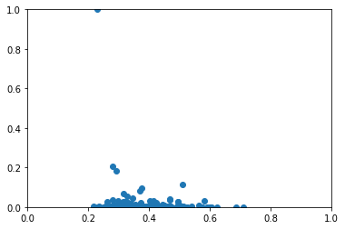

```python
plt.scatter(df_target.Predisposition, df_target.Penetration)
plt.xlim([0, 1])
plt.ylim([0, 1])
plt.show()
```

```python
df_target = df_target.sort_values(by='goal', ascending=False).iloc[:3]
```

```python
target_sections = list(df_target.Section.apply(lambda x: str(int(x))))
```

```python
target_sections
```

```
['130801003', '130808004', '130807007']
```

```python
polys = pd.read_pickle('poligonos.pkl')[['geometry', 'ID']]
```

```python
polys['Z'] = polys['ID'].apply(lambda x: 1 if x in target_sections else 0)
```

```python
df_plot = geopandas.GeoDataFrame(data=polys)
```

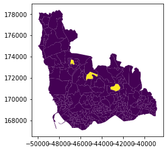

```python
df_plot.plot('Z')
```

###### Map General Optimized Potential

```python
opt_pot = pd.read_pickle('Optimized_Potential.pkl').set_index('Section')
```

```python
opt_pot.head()
```

[output not shown]

```python
opt_pot.Section.loc[0]
```

```
'130801001'
```

```python
polys_gene = polys.join(opt_pot, on='ID')
```

```python
df_general_plot = geopandas.GeoDataFrame(data=polys_gene)
```

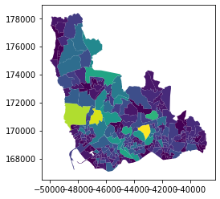

```python
df_general_plot.plot('#Scooters')
```

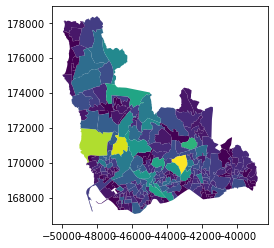

```python
df_general_plot.plot('#Bikes')
```

### III. Predisposition Predictive Model

Predictive model that uses the demographic data to predict the penetration of a certain locality (high/low) The input data was the processed censos dataset (explained above)

#### Get Data

```python
censos = pd.read_csv('score_censos_zonas.csv')
censos = censos.rename(columns={'GEO_COD': 's1'})
censos.head(5)
```

|  | s1 | N_ALOJAMENTOS_RES_HABITUAL | N_RES_HABITUAL_ESTAC_1 | N_RES_HABITUAL_ESTAC_2 | N_RES_HABITUAL_ESTAC_3 | N_FAMILIAS_CLASSICAS_1OU2_PESS | N_FAMILIAS_CLASSICAS_3OU4_PESS | N_FAMILIAS_CLASSICAS_NPES65 | N_NUCLEOS_FILH_INF_6ANOS | N_NUCLEOS_FILH_INF_15ANOS | N_NUCLEOS_FILH_MAIS_15ANOS | N_INDIVIDUOS_RESIDENT | N_IND_RESID_ESTUD_MUN_RESID | N_IND_RESID_TRAB_MUN_RESID |
| --- | --- | --- | --- | --- | --- | --- | --- | --- | --- | --- | --- | --- | --- | --- |
| 0 | 130801001 | 230 | -50 | -52 | -51 | 262 | -78 | -170 | -44 | -53 | 154 | 606 | 210 | 480 |
| 1 | 130801002 | 203 | -64 | -48 | -27 | 198 | -89 | -144 | -48 | -47 | 158 | 547 | 249 | 393 |
| 2 | 130801003 | 217 | -86 | -68 | -48 | 220 | -93 | -166 | -42 | -56 | 154 | 1171 | 585 | 1401 |
| 3 | 30801004 | 264 | -126 | -76 | -15 | 276 | -109 | -188 | -84 | -72 | 142 | 676 | 297 | 492 |
| 4 | 130801005 | 273 | -176 | -96 | -60 | 146 | -189 | -96 | -96 | -113 | 222 | 813 | 492 | 723 |

```python
pen = pd.read_pickle('season1_penetration.pkl')
pen = pen[['indexPenetration']]
pen.head(5)
```

| s1 | indexPenetration |
| --- | --- |
| 130806007 | 0.054902 |
| 130806039 | 0.028076 |
| 130806041 | 0.011488 |
| 130806043 | 0.008202 |
| 130806012 | 0.007683 |

```python
data = censos.join(pen, on='s1')
data.head(5)
```

|  | s1 | N_ALOJAMENTOS_RES_HABITUAL | N_RES_HABITUAL_ESTAC_1 | N_RES_HABITUAL_ESTAC_2 | N_RES_HABITUAL_ESTAC_3 | N_FAMILIAS_CLASSICAS_1OU2_PESS | N_FAMILIAS_CLASSICAS_3OU4_PESS | N_FAMILIAS_CLASSICAS_NPES65 | N_NUCLEOS_FILH_INF_6ANOS | N_NUCLEOS_FILH_INF_15ANOS | N_NUCLEOS_FILH_MAIS_15ANOS | N_INDIVIDUOS_RESIDENT | N_IND_RESID_ESTUD_MUN_RESID | N_IND_RESID_TRAB_MUN_RESID | indexPenetration |
| --- | --- | --- | --- | --- | --- | --- | --- | --- | --- | --- | --- | --- | --- | --- | --- |
| 0 | 130801001 | 230 | -50 | -52 | -51 | 262 | -78 | -170 | -44 | -53 | 154 | 606 | 210 | 480 | 0.0 |
| 1 | 130801002 | 203 | -64 | -48 | -27 | 198 | -89 | -144 | -48 | -47 | 158 | 547 | 249 | 393 | 0.0 |
| 2 | 130801003 | 217 | -86 | -68 | -48 | 220 | -93 | -166 | -42 | -56 | 154 | 1171 | 585 | 1401 | 0.0 |
| 3 | 30801004 | 264 | -126 | -76 | -15 | 276 | -109 | -188 | -84 | -72 | 142 | 676 | 297 | 492 | NaN |
| 4 | 130801005 | 273 | -176 | -96 | -60 | 146 | -189 | -96 | -96 | -113 | 222 | 813 | 492 | 723 | 0.0 |

#### Overview of Modelling Approaches Used

```python
# Maximum penetration index
data['indexPenetration'].max()
```

```
0.054901834877113
```

```python
def process_data_classification(data, subsample=False, test_split=0.2, normalization = True, validation_split=0.2, random_st=np.random.RandomState(30), show_prints=True):

    if subsample:

        pos = data.loc[data['label'] == 1]
        neg = data.loc[data['label'] == 0]

        if len(pos) > len(neg):
            pos = pos.sample(n=len(neg), axis=0)
        if len(neg) > len(pos):
            neg = neg.sample(n=len(pos), axis=0)
        data = pd.concat([neg, pos], ignore_index=True)

    if show_prints:
        print("\nNumber of samples: ", len(data))
        print(Counter(data['label']))

    labels=data['label']
    data=data.drop(columns=['label', 'indexPenetration', 's1'])

    #Divide in train + test
    X_train, X_test, y_train, y_test = train_test_split(data, labels, shuffle=True, test_size=test_split, random_state=random_st)

    if normalization:
        scaler = StandardScaler()
        X_train = scaler.fit_transform(X_train) #normalize features
        X_test = scaler.transform(X_test)

    if show_prints:
        print("\nTrain size: ", len(X_train))

        print("Test size: ", len(X_test))

        print("\nTrain:")
        print(Counter(y_train))
        print("0 - {:.2f} %".format((Counter(y_train)[0.0]/(Counter(y_train)[0.0]+Counter(y_train)[1.0]))*100))
        print("1 - {:.2f} %".format((Counter(y_train)[1.0]/(Counter(y_train)[0.0]+Counter(y_train)[1.0]))*100))

        print("\nTest:")
        print(Counter(y_test))
        print("0 - {:.2f} %".format((Counter(y_test)[0.0]/(Counter(y_test)[0.0]+Counter(y_test)[1.0]))*100))
        print("1 - {:.2f} %".format((Counter(y_test)[1.0]/(Counter(y_test)[0.0]+Counter(y_test)[1.0]))*100))

        return X_train, X_test, y_train, y_test
```

```python
# Process data

# If penetration index a is >= median(penetration index), we consider that is a high value (positive class), else it is low (negative class)
# We wanted to use a threshold value with more meaning (for example, 1%), but the data would be too inbalanced, so this proof of concept uses de meadian as threshold
data['label'] = data['indexPenetration'].apply(lambda x: 1 if x >= data['indexPenetration'].median() else 0)
X_train, X_test, y_train, y_test = process_data_classification(data, subsample=True, test_split=0.2, normalization=True, validation_split=0.2, random_st=42, show_prints=True)

y_train = y_train.to_numpy().astype(int)
y_test = y_test.to_numpy().astype(int)
```

```
Number of samples:  250
Counter({0: 125, 1: 125})

Train size:  200
Test size:  50

Train:
Counter({1: 102, 0: 98})
0 - 49.00 %
1 - 51.00 %

Test:
Counter({0: 27, 1: 23})
0 - 54.00 %
1 - 46.00 %
```

```python
param_grid = {'C': [100,10, 1, .1, 0.01, 0.001,],
               'solver': ['newton-cg', 'liblinear', 'lbfgs'],
                 'max_iter': [100, 200, 1000]}

model = LogisticRegression(random_state=42)

grid = GridSearchCV(model, param_grid, n_jobs = -1, refit = False, verbose=1, return_train_score = True, scoring = {'accuracy'})
grid.fit(X_train, y_train)

results = pd.DataFrame(grid.cv_results_)

results = results.sort_values(by = ['mean_test_accuracy'], ascending = False)

best_results = results.iloc[0]

PARAMS = best_results['params']

print("Best params: ", PARAMS)

best_model = model.set_params(**PARAMS)
best_model.fit(X_train, y_train)
```

```
Fitting 5 folds for each of 54 candidates, totalling 270 fits
Best params:  {'C': 1, 'max_iter': 100, 'solver': 'newton-cg'}
```

```
LogisticRegression(C=1, random_state=42, solver='newton-cg')
```

### Evaluation and discussion of results and model performance

```python
 def evaluate_model(X_train, y_train, X_test, y_test, clf):

    y_pred_train = clf.predict(X_train)
    y_pred_test = clf.predict(X_test)

    train_acc = balanced_accuracy_score(y_train, y_pred_train)
    test_acc = balanced_accuracy_score(y_test, y_pred_test)

    train_f1 = f1_score(y_train, y_pred_train)
    test_f1 = f1_score(y_test, y_pred_test)

    fig_cm_train,ax = plt.subplots()
    plot_confusion_matrix(clf, X_train, y_train, ax=ax, cmap='YlGnBu')
    ax.set_title("Train CM")

    fig_cm_test,ax = plt.subplots()
    plot_confusion_matrix(clf, X_test, y_test, ax=ax, cmap='YlGnBu')
    ax.set_title("Test CM")

    print("\nTrain results:\nAccuracy={:.3f}\nF1={:.3f}\n".format(train_acc, train_f1))
    print("\n\nTest results:\nAccuracy={:.3f}\nF1={:.3f}\n".format(test_acc, test_f1))
```

```
Train results:
Accuracy=0.685
F1=0.690



Test results:
Accuracy=0.610
F1=0.630
```

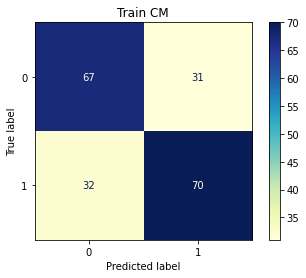

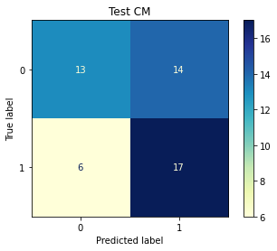

```python
evaluate_model(X_train, y_train, X_test, y_test, best_model)
```

### Model Interpretability and Fairness

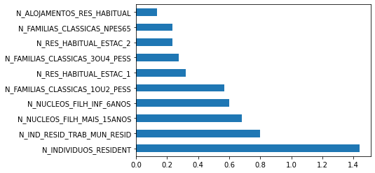

```python
features_names=data.drop(columns=['label', 'indexPenetration', 's1']).columns
pd.Series(abs(best_model.coef_[0]), index=features_names).nlargest(10).plot(kind='barh')
```